# Logistic regression assignment, group 3

Elizabeth Machkovska, Letícia Marçal Russo, Madio Seck, William Schaafsma

31 January, 2022

# 1 Context

The World Health Organization (WHO) estimated that 17.9 million people die each year from cardiovascular diseases (CVDs), globally. That is an estimated 32% of all deaths worldwide. Heart failure is most commonly caused by CVDs. Some people have inherited cardiac conditions but there are several behavioural factors that increase risk of heart failure: unhealthy diet, drug use, lack of exercise. Those behaviours can lead to individual raised cholesterol, blood pressure, etc. This dataset holds 11 variables that may predict heart failure, on which we will elaborate later on. In this assignment we will try to develop a model that overall, is accurate in predicting heart failure (or not) with new patients’ data. One could understand that such a model has a worldwide relevance.

# 2 Packages

```r
library(ggplot2)
library(tidyr)
library(GGally)
library(readr)
library(dbplyr)
library(tidyverse)
library(magrittr)
library(lattice)
library(correlation)
library(ggcorrplot)
library(see)
library(caret)
library(greybox)
library(summarytools)
library(DAAG)
library(fastDummies)
library(pROC)
library(ROCR)
```

# 3 Research question

As we already mentioned, our goal is to make accurate predictions for new patients’ data. Therefore we tend not to focus that much on inference. We will split our data into training data and testing data. We will build our model in the training data and then test our model / make predictions in the testing data. When interpreting output, we will work with a significance level of alpha 5% (p < 0.05) and a confidence interval (CI) of 95%.

In this assignment we will do an exploratory analysis on the variables that could predict heart disease.

Consequently, we will not work with hypothesis. Since we will try to build a model by exploratory means, our research question states:

**When using exploratory data analysis, what variables seem to be influential predicting heart disease?**

# 4 Loading the dataset

The data set is derived from Kaggle and is uploaded by fedesoriano (2021). With the following script a distinction is made between continuous (numeric) and categorical variables which are transformed to factor type data.

```r
heart <- read_csv("heart.csv",
                  col_types = cols(Age = col_number(),
                                   Sex = col_factor(),
                                   ChestPainType = col_factor(),
                                   RestingBP = col_number(),
                                   Cholesterol = col_number(),
                                   FastingBS = col_factor(),
                                   RestingECG = col_factor(),
                                   MaxHR = col_number(),
                                   ExerciseAngina = col_factor(),
                                   Oldpeak = col_number(),
                                   ST_Slope = col_factor(),
                                   HeartDisease = col_factor()
                   )
                  )
heart$FastingBS <- factor(heart$FastingBS,
                                labels = c("B120", "A120"))
heart$HeartDisease <- factor(heart$HeartDisease,
                                labels = c("Norm", "Prob"))
```

# 5 Explanation of the variables

This data set holds 12 variables of which **Heart disease** is our dichotomous outcome variable. A futher elaboration on the variables follows:

**Variable 1**: *Age*. It’s a numeric variable of the patients’ age expressed in years.

**Variable 2**: *Sex*. It’s a categorical variable which holds the groups: F = female & M = male.

**Variable 3**: *ChestPaintype*. It’s a categorical variable which contains 4 different types of chest pains.

*TA*: Typical Angina, a type of chest pain caused by reduced blood flow to the heart.

*ATA*: Atypical Angina, a type of chest pain that doesn’t meet the criteria for angina.

*NAP*: Non-Anginal Pain, a type of chest pain that is not caused by heart disease or a heart attack.

*ASY*: Asymptomatic, a type of chest pain that includes no chest pain but there is angina.

**Variable 4**: *RestingBP*. It’s a numeric variable representing patients’ resting blood pressure (mmHg). The average blood pressure for an adult male is 120/80 mmHg. Average blood pressure increases when people get older. Furthermore, women’s average blood pressure is mostly a little bit lower compared to males. A resting blood pressure > 140 is considered high and may cause heart failure.

**Variable 5**: *Cholesterol*. It’s a numeric variable representing patients’ cholesterol levels (mm / dl). A healthy adult has a cholesterol level lower than 200 mm / dl. High cholesterol levels (> 240) is moderate/high and therefore may cause heart failure.

**Variable 6**: *FastingBS*. It’s a dichotomous variable representing patients’ fasting blood sugar (mg / dl). Fasting blood sugar levels > 120 mg / dl are coded as a 1. Fasting blood sugar levels < 120 mg / dl are coded as a 0. High levels of blood sugar infer diabetes which may cause heart failure.

**Variable 7**: *RestingECG*. It’s a categorical variable which contains 3 different types of electric activity in the heart.

*Normal*: The heart is beating in a regular sinus rhythm at a normal pace. No danger whatsoever.

*ST*: Indicates an abnormality in the heartbeat. It is associated with increased cardiovascular risk.

*LVH*: This activity in the heart represents valve problems which increasingly thickens the wall of the heart’s main pumping chamber. It’s the most common cause of high blood pressure which may cause heart failure.

**Variable 8**: *MaxHR*. It’s a numeric variable that represents the patients’ maximum heart rate. Maximum heart rate is related to age since it’s calculated by subtracting 220 by one’s age. Exceeding the maximum heart rate, depending on one’s age, is dangerous for the heart and may induce heart failure. Logically, a 70-year-old patient has a lower maximum heart rate than a 30-year-old patient.

**Variable 9**: *Exercise Angina*. It’s a categorical variable having two categories. This variable takes into account whether people experience angina after exercise. Y = yes and N = no. People that experience angina after exercise may be more vulnerable to heart disease.

**Variable 10**: *Oldpeak*. It’s a numeric variable which indicates that the trace within the ST segment is abnormally below the baseline. The value is measured in depression. ST segment depression correlates to people with angina and thus may predict heart failure.

**Variable 11**: *ST_slope*. It’s a categorical variable which indicates whether the slope between the S and the T is “Down”, “Flat” or “Up”. Here a downsloping ST segment is very bad since it’s a manifestation of severe myocardial ischemia which may induce heart failure.

**Variable 12**: *HeartDisease*. It’s a dichotomous variable and our outcome variable is this assignment. 0 means ‘no heart disease / normal’ 1 means ‘heart disease’

# 6 Inspecting and cleaning up

We will work with a dataset that has 918 observations and 12 variables. We will inspect it, look for any anomaly and fix it in case we find it. After that, we will split the data in train and test sets.

```r
head(heart) %>%
  knitr::kable(format = "markdown", digits= 1, padding = 30, align = 'c')
```

| Age | Sex | ChestPainType | RestingBP | Cholesterol | FastingBS | RestingECG | MaxHR | ExerciseAngina | Oldpeak | ST_Slope | HeartDisease |
| --- | --- | --- | --- | --- | --- | --- | --- | --- | --- | --- | --- |
| 40 | M | ATA | 140 | 289 | B120 | Normal | 172 | N | 0.0 | Up | Norm |
| 49 | F | NAP | 160 | 180 | B120 | Normal | 156 | N | 1.0 | Flat | Prob |
| 37 | M | ATA | 130 | 283 | B120 | ST | 98 | N | 0.0 | Up | Norm |
| 48 | F | ASY | 138 | 214 | B120 | Normal | 108 | Y | 1.5 | Flat | Prob |
| 54 | M | NAP | 150 | 195 | B120 | Normal | 122 | N | 0.0 | Up | Norm |
| 39 | M | NAP | 120 | 339 | B120 | Normal | 170 | N | 0.0 | Up | Norm |

Apparently, none of the variables have missing values, but we will get more insights in the descriptive analysis.

```r
summary(heart)
```

```
##       Age        Sex     ChestPainType   RestingBP      Cholesterol
##  Min.   :28.00   M:725   ATA:173       Min.   :  0.0   Min.   :  0.0
##  1st Qu.:47.00   F:193   NAP:203       1st Qu.:120.0   1st Qu.:173.2
##  Median :54.00           ASY:496       Median :130.0   Median :223.0
##  Mean   :53.51           TA : 46       Mean   :132.4   Mean   :198.8
##  3rd Qu.:60.00                         3rd Qu.:140.0   3rd Qu.:267.0
##  Max.   :77.00                         Max.   :200.0   Max.   :603.0
##  FastingBS   RestingECG      MaxHR       ExerciseAngina    Oldpeak
##  B120:704   Normal:552   Min.   : 60.0   N:547          Min.   :-2.6000
##  A120:214   ST    :178   1st Qu.:120.0   Y:371          1st Qu.: 0.0000
##             LVH   :188   Median :138.0                  Median : 0.6000
##                          Mean   :136.8                  Mean   : 0.8874
##                          3rd Qu.:156.0                  3rd Qu.: 1.5000
##                          Max.   :202.0                  Max.   : 6.2000
##  ST_Slope   HeartDisease
##  Up  :395   Norm:410
##  Flat:460   Prob:508
##  Down: 63
##
##
##
```

This dataset contains information about 918 people of which 725 are males. What strikes is that resting blood pressure and cholesterol have some 0 values. What’s great is that our outcome variable “heart disease”, is nearly 50/50 for Norm and Prob. Finally, zero values in resting blood pressure and cholesterol may be missing values and looking at the interquartile range from max heart rate there may be some outliers between the min and 1st quartile. Apparently, none of the variables have missing values, but we will get more insights in the descriptive analysis.

```r
str(heart)
```

```
## spec_tbl_df [918 x 12] (S3: spec_tbl_df/tbl_df/tbl/data.frame)
##  $ Age           : num [1:918] 40 49 37 48 54 39 45 54 37 48 ...
##  $ Sex           : Factor w/ 2 levels "M","F": 1 2 1 2 1 1 2 1 1 2 ...
##  $ ChestPainType : Factor w/ 4 levels "ATA","NAP","ASY",..: 1 2 1 3 2 2 1 1 3 1 ...
##  $ RestingBP     : num [1:918] 140 160 130 138 150 120 130 110 140 120 ...
##  $ Cholesterol   : num [1:918] 289 180 283 214 195 339 237 208 207 284 ...
##  $ FastingBS     : Factor w/ 2 levels "B120","A120": 1 1 1 1 1 1 1 1 1 1 ...
##  $ RestingECG    : Factor w/ 3 levels "Normal","ST",..: 1 1 2 1 1 1 1 1 1 1 ...
##  $ MaxHR         : num [1:918] 172 156 98 108 122 170 170 142 130 120 ...
##  $ ExerciseAngina: Factor w/ 2 levels "N","Y": 1 1 1 2 1 1 1 1 2 1 ...
##  $ Oldpeak       : num [1:918] 0 1 0 1.5 0 0 0 0 1.5 0 ...
##  $ ST_Slope      : Factor w/ 3 levels "Up","Flat","Down": 1 2 1 2 1 1 1 1 2 1 ...
##  $ HeartDisease  : Factor w/ 2 levels "Norm","Prob": 1 2 1 2 1 1 1 1 2 1 ...
##  - attr(*, "spec")=
##   .. cols(
##   ..   Age = col_number(),
##   ..   Sex = col_factor(levels = NULL, ordered = FALSE, include_na = FALSE),
##   ..   ChestPainType = col_factor(levels = NULL, ordered = FALSE, include_na = FALSE),
##   ..   RestingBP = col_number(),
##   ..   Cholesterol = col_number(),
##   ..   FastingBS = col_factor(levels = NULL, ordered = FALSE, include_na = FALSE),
##   ..   RestingECG = col_factor(levels = NULL, ordered = FALSE, include_na = FALSE),
##   ..   MaxHR = col_number(),
##   ..   ExerciseAngina = col_factor(levels = NULL, ordered = FALSE, include_na = FALSE),
##   ..   Oldpeak = col_number(),
##   ..   ST_Slope = col_factor(levels = NULL, ordered = FALSE, include_na = FALSE),
##   ..   HeartDisease = col_factor(levels = NULL, ordered = FALSE, include_na = FALSE)
##   .. )
##  - attr(*, "problems")=<externalptr>
```

# 7 Descriptive analysis

Now that we know what the variables consist of and the meaning behind them we will be looking some analysis on the distribution of the observations for each variable.

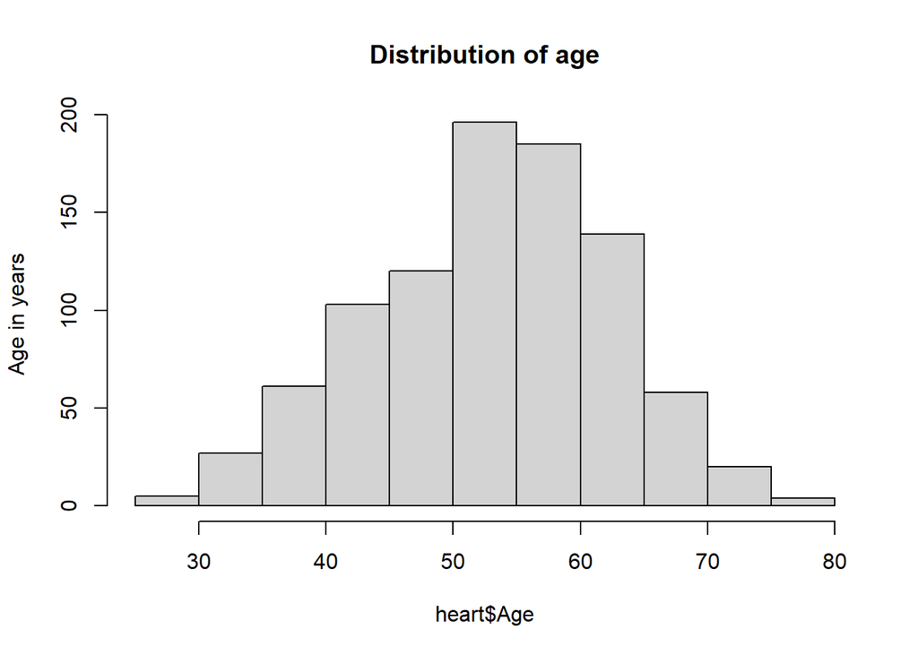

```r
Hist_age <- hist(heart$Age, main = "Distribution of age", ylab = "Age in years")
```

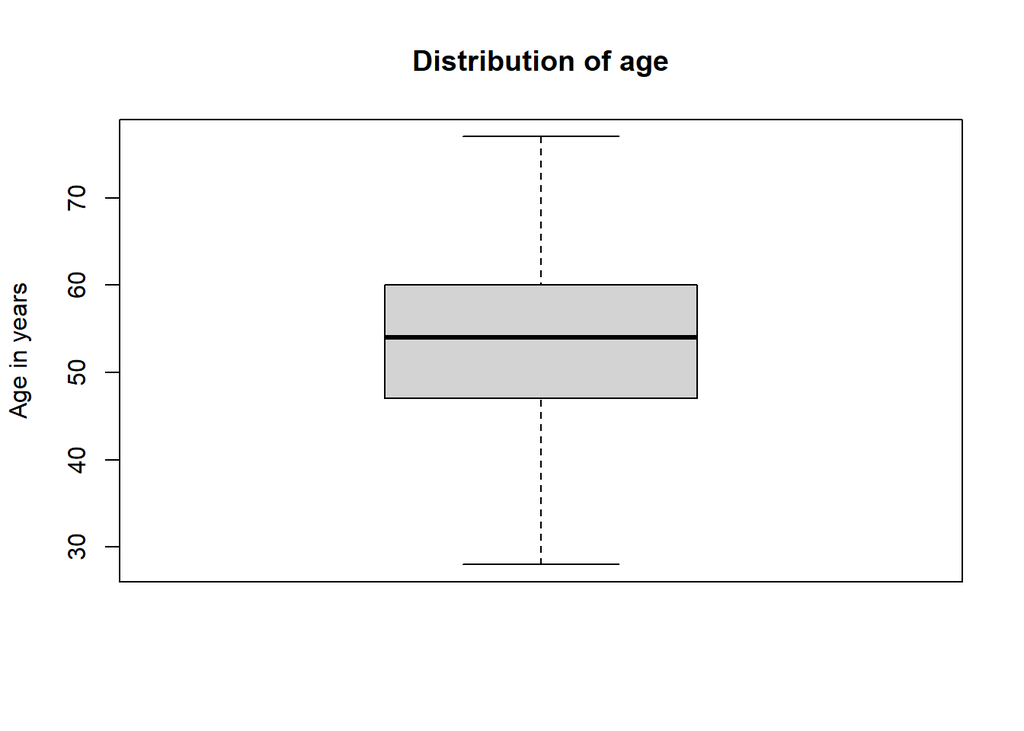

```r
Box_age <- boxplot(heart$Age, main = "Distribution of age", ylab = "Age in years")
```

```r
median(heart$Age)
```

```
## [1] 54
```

Age is distributed normally. The youngest observations is 28 years old and the oldest observation is 77 years old. The median of this data set is 54 and there are no outliers.

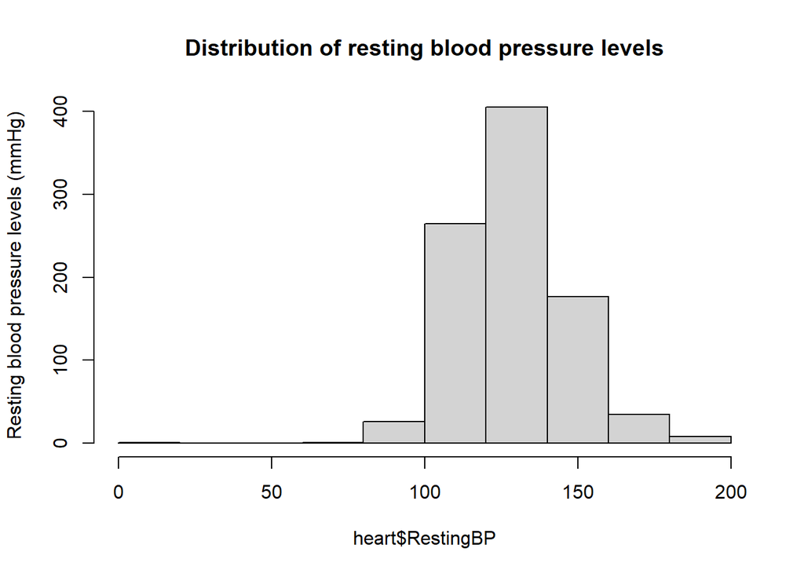

```r
Hist_BPrest <- hist(heart$RestingBP, main = "Distribution of resting blood pressure levels", ylab = "Resting blood pressure levels (mmHg)")
```

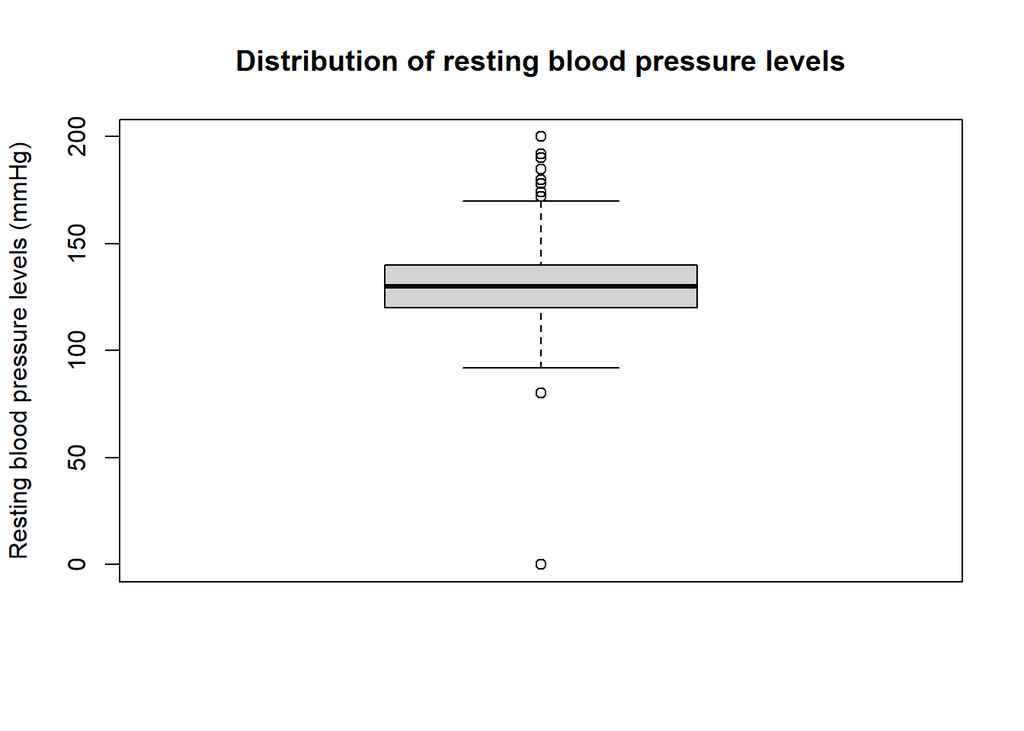

```r
Box_BPrest <- boxplot(heart$RestingBP, main = "Distribution of resting blood pressure levels", ylab = "Resting blood pressure levels (mmHg)")
```

```r
median(heart$RestingBP)
```

```
## [1] 130
```

```r
max(heart$RestingBP)
```

```
## [1] 200
```

Most of the observations have a healthy resting blood pressure, which the median of 130 also represents. There are some outliers past the maximum of the boxplot, the highest observations has a resting blood pressure of 200 which is very dangerous.

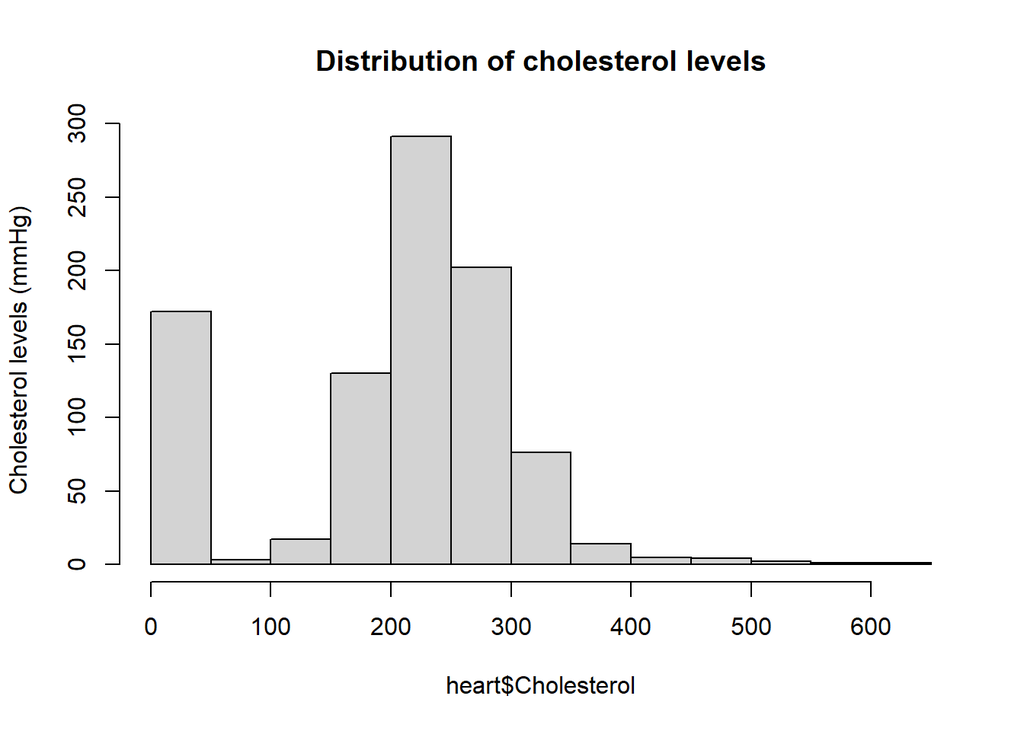

```r
Hist1_chol <- hist(heart$Cholesterol, main = "Distribution of cholesterol levels", ylab = "Cholesterol levels (mmHg)")
```

[figure not shown]

```r
Box_chol <- boxplot(heart$Age, main = "Distribution of cholesterol levels", ylab = "Cholesterol levels (mm / dl)")
```

```r
min(heart$Cholesterol)
```

```
## [1] 0
```

```r
max(heart$Cholesterol)
```

```
## [1] 603
```

```r
median(heart$Cholesterol)
```

```
## [1] 223
```

The Cholesterol variable has 172 observations of the number 0. It is not possible that a person has zero cholesterol level. Therefore, we will consider this information as error and, consequently, missing values.

Due to 172 observations of the dataset (almost 20%) having the value of 0 for the variable cholesterol, it is not possible to simply remove those observations from the dataset. It would be better to entirely remove the variable then, but it is still yet uncertain whether cholesterol is related to heart disease. To determine that we need to see if cholestorol has any correlation to heart disease after removing the 0 observations.

```
## For i = 2 j = 1  A cell entry of 0 was replaced with correct =  0.5.  Check your data!
```

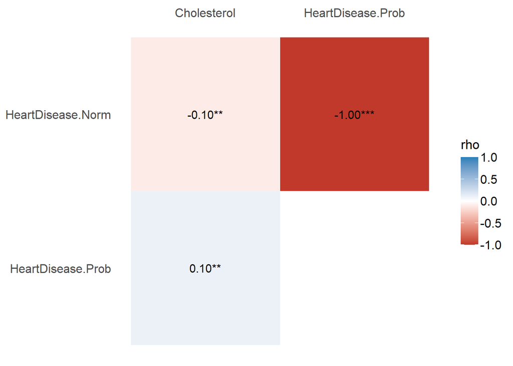

```r
# Excluding the 0 values
heart_cholesterol <- heart %>%
                     filter(!Cholesterol == 0)

heart_cholesterol %>%
  select(HeartDisease, Cholesterol) %>%
  correlation(include_factors = TRUE, method = "auto") %>%
  summary() %>%
    plot(show_labels=TRUE,
       show_p=TRUE,
       size_point=5,
       size_text=4,
       digits=2,
       type="tile",
       )
```

From this we can determine that cholesterol has a very weak correlation. So to we have come to the decision to exclude the cholesterol variable.

```r
Clean_Heart <- heart %>%
               select(!Cholesterol)
```

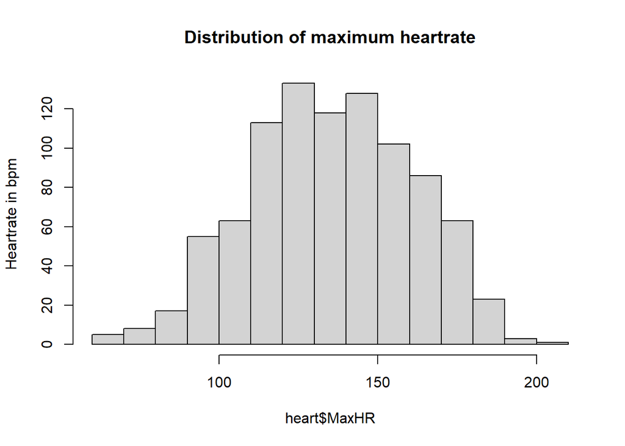

```r
hist_MaxHR <- hist(heart$MaxHR, main = "Distribution of maximum heartrate", ylab = "Heartrate in bpm")
```

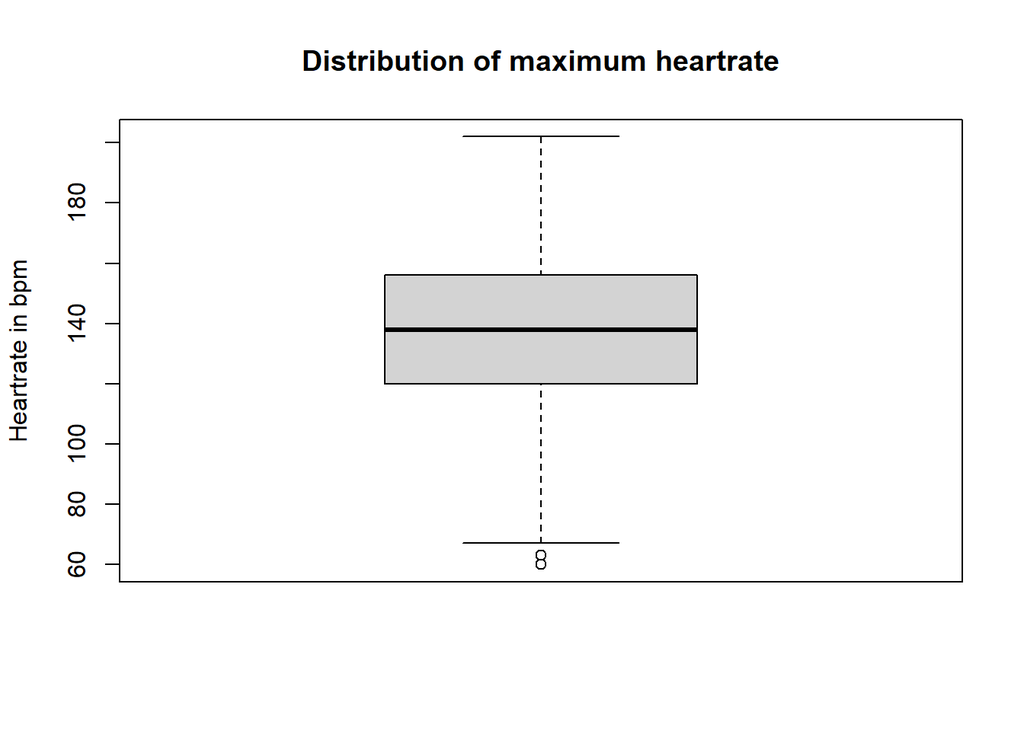

```r
Box_maxhr <- boxplot(heart$MaxHR, main = "Distribution of maximum heartrate", ylab = "Heartrate in bpm")
```

```r
min(heart$MaxHR)
```

```
## [1] 60
```

```r
max(heart$MaxHR)
```

```
## [1] 202
```

```r
median(heart$MaxHR)
```

```
## [1] 138
```

Heartrate has a normal distribution and a couple outliers on the lower side, but nothing that doesn’t fit the variable. The median maximum heart rate is 138 bpm which is average and within the norms for the median age of the observant. The highest is 202, which is definitely on the higher side and not healthy and the lowest is 60, which also isn’t very healthy.

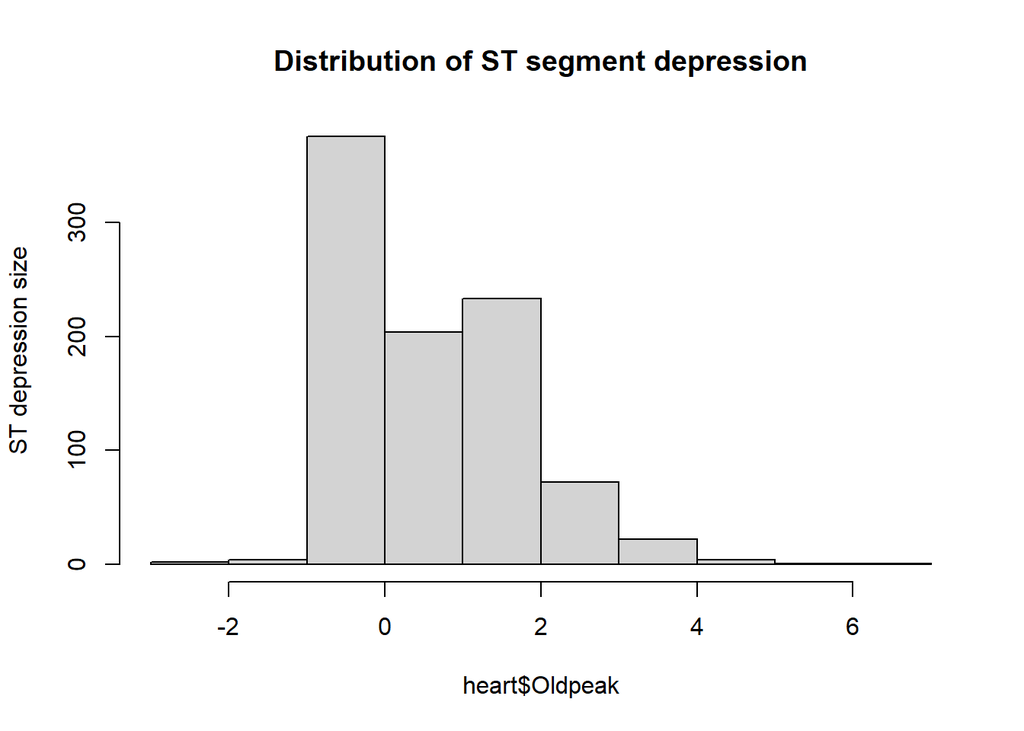

```r
hist_oldPeak <- hist(heart$Oldpeak, main = "Distribution of ST segment depression", ylab = "ST depression size")
```

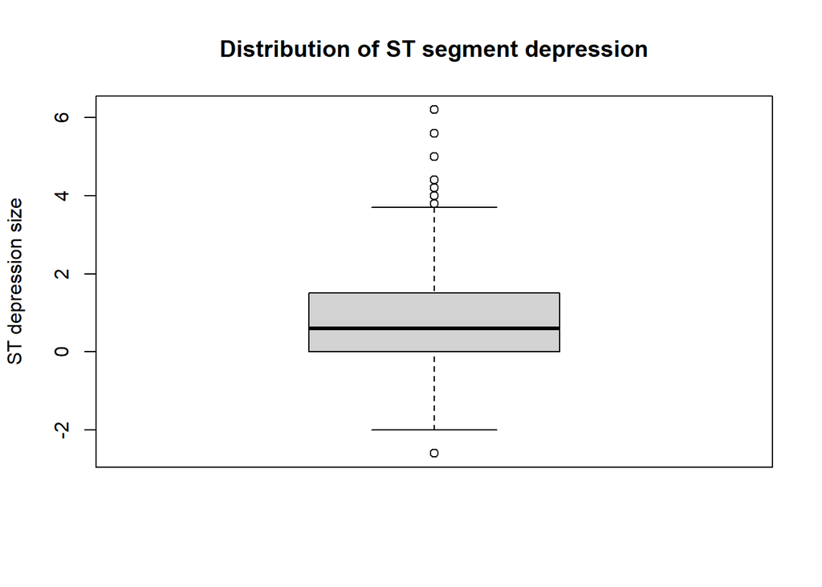

```r
Box_oldPeak <- boxplot(heart$Oldpeak, main = "Distribution of ST segment depression", ylab = "ST depression size")
```

```r
min(heart$Oldpeak)
```

```
## [1] -2.6
```

```r
max(heart$Oldpeak)
```

```
## [1] 6.2
```

```r
median(heart$Oldpeak)
```

```
## [1] 0.6
```

# 8 Split the data: train and test

We will now split the data in two subsets, in order to train our model in the first set and check its performance in the second one.

The train set will have 80% of the observations (735), and the test will be left with the other 20% (183 observations).

Out of the 735 observations from the training set, 45% has normal heart performance (328 rows) and 55% has heart problems (407 rows). Therefore, the training data has approximately equal distribution of classes within response variable.

```r
set.seed(42)

# Split data randomly
trainDataIndex <- createDataPartition(Clean_Heart$HeartDisease,
                                      p = 0.8,
                                      list = FALSE)

# Create training and testing set
train_heart <- Clean_Heart[trainDataIndex, ]
test_heart <- Clean_Heart[-trainDataIndex, ]

table(train_heart$HeartDisease)
```

```
##
## Norm Prob
##  328  407
```

# 9 Correlation

The **easystats** package by Makowski and his colleagues (2019) and the **greybox** package by Svetunkov and Yves (2022) is used to create the pairwise correlation matrix. The long variable names are first shortened to make visualization neater.

```r
# Make the names shorter
train_heart$CPT <- train_heart$ChestPainType
train_heart$R_BP <- train_heart$RestingBP
train_heart$F_BS <- train_heart$FastingBS
train_heart$R_ECG <- train_heart$RestingECG
train_heart$E_A <- train_heart$ExerciseAngina
train_heart$ST_S <- train_heart$ST_Slope
train_heart$H_D <- train_heart$HeartDisease
```

## 9.1 Continuous predictors

Correlation between continuous predictor variables and dichotomous categorical outcome variable is calculated using the *Point-biserial* correlation. Regarding nominal variables, the coefficient does tell something about the strength of a relation, however, not about the direction, even though those are visualised in the matrix for *H_D*. The relationship between continuous predictors is measured using *Pearson*.

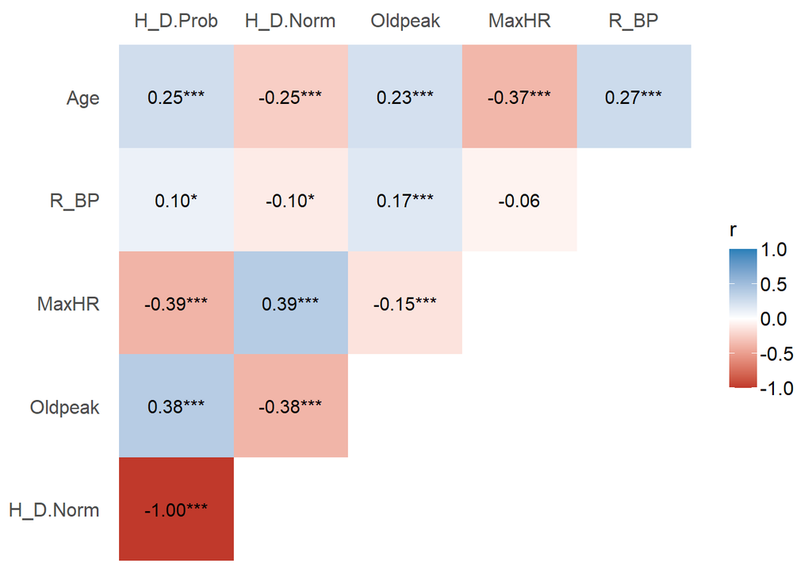

```r
train_heart %>%
  select(Age, R_BP, MaxHR, Oldpeak, H_D) %>%
  correlation(include_factors = TRUE, method = "auto") %>%
  summary() %>%
    plot(show_labels=TRUE,
       show_p=TRUE,
       size_point=5,
       size_text=4,
       digits=2,
       type="tile",
       )
```

## 9.2 Categorical predictors

The *Cramer’s V* is used for categorical variables.

```r
train_heart %>%
  select(CPT, R_ECG, ST_S, H_D) %>%
  assoc() %>%
  print(digits = 2)
```

```
## Associations:
## values:
##        CPT R_ECG ST_S  H_D
## CPT   1.00  0.09 0.27 0.54
## R_ECG 0.09  1.00 0.07 0.11
## ST_S  0.27  0.07 1.00 0.61
## H_D   0.54  0.11 0.61 1.00
##
## p-values:
##        CPT R_ECG ST_S  H_D
## CPT   0.00  0.06 0.00 0.00
## R_ECG 0.06  0.00 0.11 0.01
## ST_S  0.00  0.11 0.00 0.00
## H_D   0.00  0.01 0.00 0.00
##
## types:
##       CPT      R_ECG    ST_S     H_D
## CPT   "none"   "cramer" "cramer" "cramer"
## R_ECG "cramer" "none"   "cramer" "cramer"
## ST_S  "cramer" "cramer" "none"   "cramer"
## H_D   "cramer" "cramer" "cramer" "none"
```

The association between binary outcome variable and predictors with more than two categories is statistically significant. The slope of peak exercise (*ST_S*) has a strong relationship with the number of heart problems. Followed by a moderately strong relationship with chest pain types (*CPT*) observed. The least strong relationship is with the results of resting electrocardiogram results (*R_ECG*), which is almost negligible. There is a significant relationship between slope and chest pain type, however it is moderate.

For binary variables, the same association measure is used.

```r
train_heart %>%
  select(Sex, F_BS, E_A, H_D) %>%
  assoc() %>%
  print(digits = 2)
```

```
## Associations:
## values:
##       Sex F_BS  E_A  H_D
## Sex  1.00 0.12 0.18 0.29
## F_BS 0.12 1.00 0.07 0.27
## E_A  0.18 0.07 1.00 0.50
## H_D  0.29 0.27 0.50 1.00
##
## p-values:
##      Sex F_BS  E_A H_D
## Sex    0 0.00 0.00   0
## F_BS   0 0.00 0.05   0
## E_A    0 0.05 0.00   0
## H_D    0 0.00 0.00   0
##
## types:
##      Sex      F_BS     E_A      H_D
## Sex  "none"   "cramer" "cramer" "cramer"
## F_BS "cramer" "none"   "cramer" "cramer"
## E_A  "cramer" "cramer" "none"   "cramer"
## H_D  "cramer" "cramer" "cramer" "none"
```

The observations of angina induced by exercise (*E_A*) correlate strongly with the heart disease. Gender (*Sex*) seems to have a moderately strong relationship with the heart disease observations. Fasting blood sugar (*F_BS*) has a weak relationship with the outcome variable.

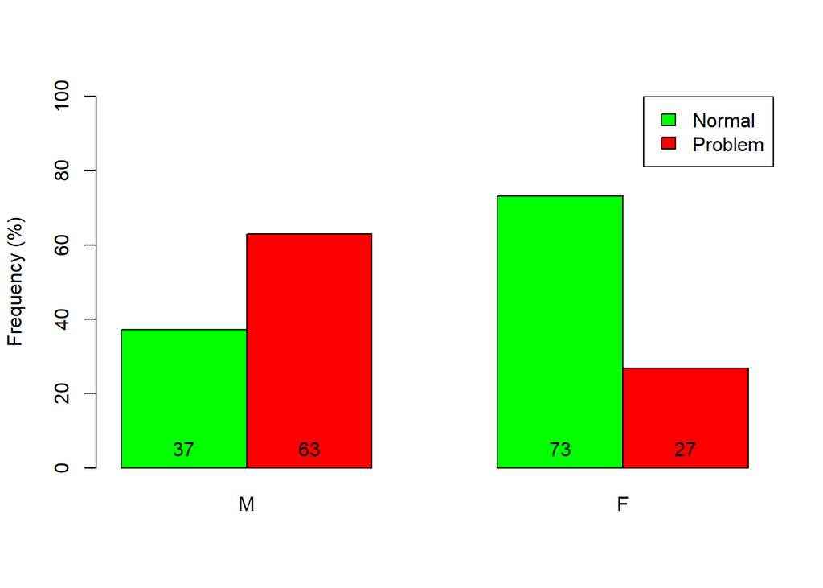

```r
tsex <- table(train_heart$HeartDisease, train_heart$Sex)
tsexp <- scale(tsex, FALSE, colSums(tsex)) * 100

bp_sex <- barplot(tsexp, beside = TRUE, col = c("green","red"), ylab="Frequency (%)", ylim=c(0,100))
legend("topright", c("Normal","Problem"), fill = c("green","red"))
text(bp_sex, 0, round(tsexp, 0), cex = 1, pos = 3)
```

In this data set men have heart problems more often than women (63% versus 27%).

```r
train_heart %$%
  ctable(HeartDisease, Sex,
    prop = "r", chisq = TRUE, headings = FALSE
  ) %>%
  print(
    method = "render",
    style = "rmarkdown",
    footnote = NA
  )
```

| **HeartDisease** | Sex M | Sex M | Sex M | Sex M | Sex F | Sex F | Sex F | Sex F | Total | Total | Total | Total |
| --- | --- | --- | --- | --- | --- | --- | --- | --- | --- | --- | --- | --- |
| **Norm** | 216 | ( | 65.9% | ) | 112 | ( | 34.1% | ) | 328 | ( | 100.0% | ) |
| **Prob** | 366 | ( | 89.9% | ) | 41 | ( | 10.1% | ) | 407 | ( | 100.0% | ) |
| **Total** | 582 | ( | 79.2% | ) | 153 | ( | 20.8% | ) | 735 | ( | 100.0% | ) |

**Χ<sup>2</sup>** = 62.4019 **df** = 1 **p** = .0000

### 9.2.1 Chest pain type

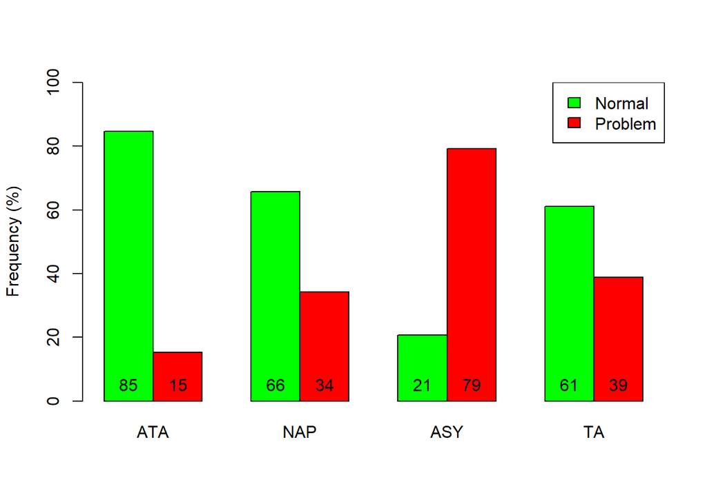

```r
tCPT <- table(train_heart$HeartDisease, train_heart$ChestPainType)
tCPTp <- scale(tCPT, FALSE, colSums(tCPT)) * 100

bp_CPT <- barplot(tCPTp, beside = TRUE, col = c("green","red"), ylab="Frequency (%)", ylim=c(0,100))
legend("topright", c("Normal","Problem"), fill = c("green","red"))
text(bp_CPT, 0, round(tCPTp, 0), cex = 1, pos = 3)
```

In this data set atypical angina (*ATA*) chest pain type has relatively more normal heart performance (85%). By contrast, asymptomatic (*ASY*) chest pain type has relatively more cases which have heart concerns (79%).

```r
train_heart %$%
  ctable(HeartDisease, ChestPainType,
    prop = "r", chisq = TRUE, headings = FALSE
  ) %>%
  print(
    method = "render",
    style = "rmarkdown",
    footnote = NA
  )
```

| **HeartDisease** | ChestPainType ATA | ChestPainType ATA | ChestPainType ATA | ChestPainType ATA | ChestPainType NAP | ChestPainType NAP | ChestPainType NAP | ChestPainType NAP | ChestPainType ASY | ChestPainType ASY | ChestPainType ASY | ChestPainType ASY | ChestPainType TA | ChestPainType TA | ChestPainType TA | ChestPainType TA | Total | Total | Total | Total |
| --- | --- | --- | --- | --- | --- | --- | --- | --- | --- | --- | --- | --- | --- | --- | --- | --- | --- | --- | --- | --- |
| **Norm** | 111 | ( | 33.8% | ) | 113 | ( | 34.5% | ) | 82 | ( | 25.0% | ) | 22 | ( | 6.7% | ) | 328 | ( | 100.0% | ) |
| **Prob** | 20 | ( | 4.9% | ) | 59 | ( | 14.5% | ) | 314 | ( | 77.1% | ) | 14 | ( | 3.4% | ) | 407 | ( | 100.0% | ) |
| **Total** | 131 | ( | 17.8% | ) | 172 | ( | 23.4% | ) | 396 | ( | 53.9% | ) | 36 | ( | 4.9% | ) | 735 | ( | 100.0% | ) |

**Χ<sup>2</sup>** = 211.8201 **df** = 3 **p** = .0000

### 9.2.2 Fasting blood sugar

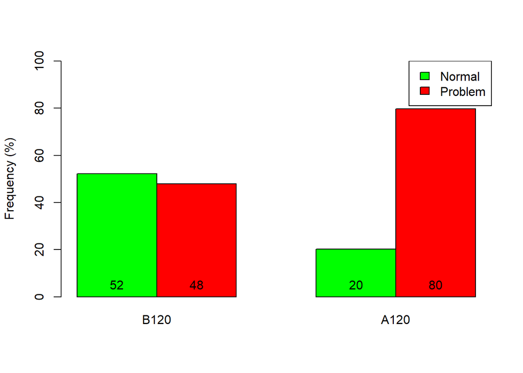

```r
tFBS <- table(train_heart$HeartDisease, train_heart$FastingBS)
tFBSp <- scale(tFBS, FALSE, colSums(tFBS)) * 100

bp_FBS <- barplot(tFBSp, beside = TRUE, col = c("green","red"), ylab="Frequency (%)", ylim=c(0,100))
legend("topright", c("Normal","Problem"), fill = c("green","red"))
text(bp_FBS, 0, round(tFBSp, 0), cex = 1, pos = 3)
```

Patients with blood sugar above 120 mg/dl have heart disease relatively more often (80% versus 48%).The association between the outcome and *A120* should be stronger.

```r
train_heart %$%
  ctable(HeartDisease, FastingBS,
    prop = "r", chisq = TRUE, headings = FALSE
  ) %>%
  print(
    method = "render",
    style = "rmarkdown",
    footnote = NA
  )
```

| **HeartDisease** | FastingBS B120 | FastingBS B120 | FastingBS B120 | FastingBS B120 | FastingBS A120 | FastingBS A120 | FastingBS A120 | FastingBS A120 | Total | Total | Total | Total |
| --- | --- | --- | --- | --- | --- | --- | --- | --- | --- | --- | --- | --- |
| **Norm** | 293 | ( | 89.3% | ) | 35 | ( | 10.7% | ) | 328 | ( | 100.0% | ) |
| **Prob** | 269 | ( | 66.1% | ) | 138 | ( | 33.9% | ) | 407 | ( | 100.0% | ) |
| **Total** | 562 | ( | 76.5% | ) | 173 | ( | 23.5% | ) | 735 | ( | 100.0% | ) |

**Χ<sup>2</sup>** = 53.2035 **df** = 1 **p** = .0000

### 9.2.3 Resting electrocardiogram

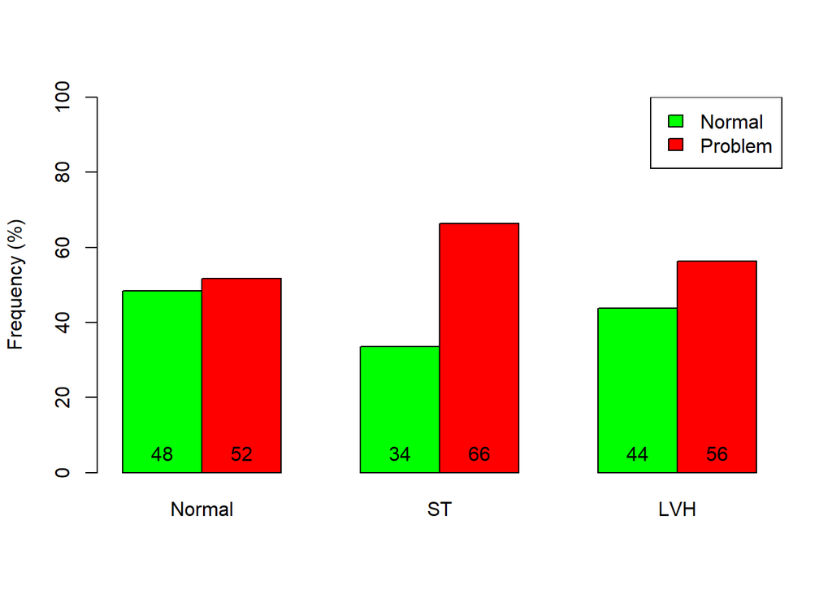

```r
tRECG <- table(train_heart$HeartDisease, train_heart$RestingECG)
tREp <- scale(tRECG, FALSE, colSums(tRECG)) * 100

bp_RE <- barplot(tREp, beside = TRUE, col = c("green","red"), ylab="Frequency (%)", ylim=c(0,100))
legend("topright", c("Normal","Problem"), fill = c("green","red"))
text(bp_RE, 0, round(tREp, 0), cex = 1, pos = 3)
```

All the resting electrocardiogram results have more than a half cases with heart problems diagnosed. The differences between classes, especially between *Normal* and *LVH* are relatively small, so it can be assumed that the association is weak.

```r
train_heart %$%
  ctable(HeartDisease, RestingECG,
    prop = "r", chisq = TRUE, headings = FALSE
  ) %>%
  print(
    method = "render",
    style = "rmarkdown",
    footnote = NA
  )
```

| **HeartDisease** | RestingECG Normal | RestingECG Normal | RestingECG Normal | RestingECG Normal | RestingECG ST | RestingECG ST | RestingECG ST | RestingECG ST | RestingECG LVH | RestingECG LVH | RestingECG LVH | RestingECG LVH | Total | Total | Total | Total |
| --- | --- | --- | --- | --- | --- | --- | --- | --- | --- | --- | --- | --- | --- | --- | --- | --- |
| **Norm** | 216 | ( | 65.9% | ) | 46 | ( | 14.0% | ) | 66 | ( | 20.1% | ) | 328 | ( | 100.0% | ) |
| **Prob** | 231 | ( | 56.8% | ) | 91 | ( | 22.4% | ) | 85 | ( | 20.9% | ) | 407 | ( | 100.0% | ) |
| **Total** | 447 | ( | 60.8% | ) | 137 | ( | 18.6% | ) | 151 | ( | 20.5% | ) | 735 | ( | 100.0% | ) |

**Χ<sup>2</sup>** = 9.2913 **df** = 2 **p** = .0096

### 9.2.4 Exercise angina

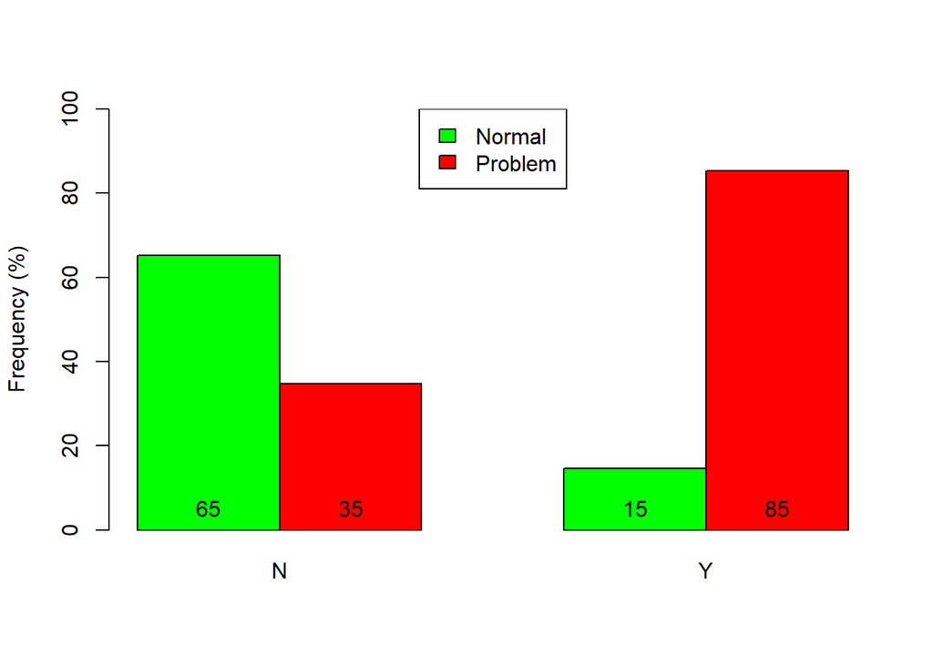

```r
tEA <- table(train_heart$HeartDisease, train_heart$ExerciseAngina)
tEAp <- scale(tEA, FALSE, colSums(tEA)) * 100

bp_EA <- barplot(tEAp, beside = TRUE, col = c("green","red"), ylab="Frequency (%)", ylim=c(0,100))
legend("top", c("Normal","Problem"), fill = c("green","red"))
text(bp_EA, 0, round(tEAp, 0), cex = 1, pos = 3)
```

Patients with angina induced by exercise (*Y*) have heart disease relatively more often (85% versus 35%). Here the differences are large, so there might be a strong relationship between *ExerciseAngina* and *HeartDisease*.

```r
train_heart %$%
  ctable(HeartDisease, ExerciseAngina,
    prop = "r", chisq = TRUE, headings = FALSE
  ) %>%
  print(
    method = "render",
    style = "rmarkdown",
    footnote = NA
  )
```

| **HeartDisease** | ExerciseAngina N | ExerciseAngina N | ExerciseAngina N | ExerciseAngina N | ExerciseAngina Y | ExerciseAngina Y | ExerciseAngina Y | ExerciseAngina Y | Total | Total | Total | Total |
| --- | --- | --- | --- | --- | --- | --- | --- | --- | --- | --- | --- | --- |
| **Norm** | 284 | ( | 86.6% | ) | 44 | ( | 13.4% | ) | 328 | ( | 100.0% | ) |
| **Prob** | 151 | ( | 37.1% | ) | 256 | ( | 62.9% | ) | 407 | ( | 100.0% | ) |
| **Total** | 435 | ( | 59.2% | ) | 300 | ( | 40.8% | ) | 735 | ( | 100.0% | ) |

**Χ<sup>2</sup>** = 182.0707 **df** = 1 **p** = .0000

### 9.2.5 St Slope

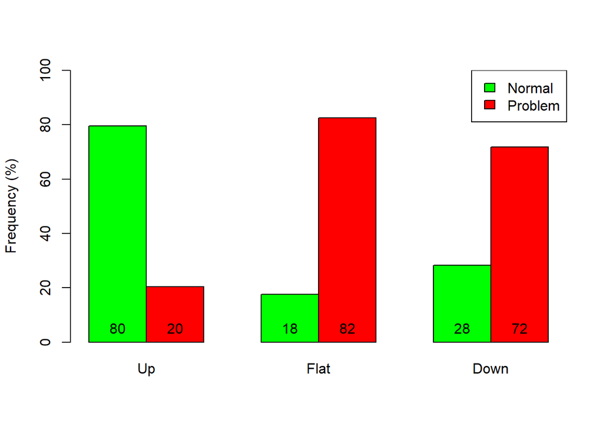

```r
tST <- table(train_heart$HeartDisease, train_heart$ST_Slope)
tSTp <- scale(tST, FALSE, colSums(tST)) * 100

bp_ST <- barplot(tSTp, beside = TRUE, col = c("green","red"), ylab="Frequency (%)", ylim=c(0,100))
legend("topright", c("Normal","Problem"), fill = c("green","red"))
text(bp_ST, 0, round(tSTp, 0), cex = 1, pos = 3)
```

```r
train_heart %$%
  ctable(HeartDisease, ST_Slope,
    prop = "r", chisq = TRUE, headings = FALSE
  ) %>%
  print(
    method = "render",
    style = "rmarkdown",
    footnote = NA
  )
```

| **HeartDisease** | ST_Slope Up | ST_Slope Up | ST_Slope Up | ST_Slope Up | ST_Slope Flat | ST_Slope Flat | ST_Slope Flat | ST_Slope Flat | ST_Slope Down | ST_Slope Down | ST_Slope Down | ST_Slope Down | Total | Total | Total | Total |
| --- | --- | --- | --- | --- | --- | --- | --- | --- | --- | --- | --- | --- | --- | --- | --- | --- |
| **Norm** | 249 | ( | 75.9% | ) | 66 | ( | 20.1% | ) | 13 | ( | 4.0% | ) | 328 | ( | 100.0% | ) |
| **Prob** | 64 | ( | 15.7% | ) | 310 | ( | 76.2% | ) | 33 | ( | 8.1% | ) | 407 | ( | 100.0% | ) |
| **Total** | 313 | ( | 42.6% | ) | 376 | ( | 51.2% | ) | 46 | ( | 6.3% | ) | 735 | ( | 100.0% | ) |

**Χ<sup>2</sup>** = 271.0210 **df** = 2 **p** = .0000

# 10 Dummy codes

The variable *ExerciseAngina* is dichotomous and *ST_Slope*, categorical. In order to use them as predictors, we need to work with dummy codes.

```r
dummy_heart <- dummy_cols(train_heart, select_columns = c('ExerciseAngina', 'ST_Slope'))
```

Now we will clean up the dataset and see how it look like.

```r
# Selecting variables we will use
dummy_heart <- dummy_heart %>%
               select(Age, MaxHR, Oldpeak,
                      ExerciseAngina, ExerciseAngina_N, ExerciseAngina_Y,
                      ST_Slope, ST_Slope_Up, ST_Slope_Down, ST_Slope_Flat,
                      HeartDisease)

# Visualizing dataset
head(dummy_heart) %>%
  knitr::kable(format = "markdown", digits= 1, padding = 30, align = 'c')
```

| Age | MaxHR | Oldpeak | ExerciseAngina | ExerciseAngina_N | ExerciseAngina_Y | ST_Slope | ST_Slope_Up | ST_Slope_Down | ST_Slope_Flat | HeartDisease |
| --- | --- | --- | --- | --- | --- | --- | --- | --- | --- | --- |
| 40 | 172 | 0 | N | 1 | 0 | Up | 1 | 0 | 0 | Norm |
| 49 | 156 | 1 | N | 1 | 0 | Flat | 0 | 0 | 1 | Prob |
| 37 | 98 | 0 | N | 1 | 0 | Up | 1 | 0 | 0 | Norm |
| 54 | 122 | 0 | N | 1 | 0 | Up | 1 | 0 | 0 | Norm |
| 39 | 170 | 0 | N | 1 | 0 | Up | 1 | 0 | 0 | Norm |
| 45 | 170 | 0 | N | 1 | 0 | Up | 1 | 0 | 0 | Norm |

We will treat *ExerciseAgina_N* (no for exercise angina) as the reference group and, therefore, only the variable *ExerciseAngina_Y* (yes for exercise angina) will be included in the model, as the focal group.

In the case of *ST_Slope*, *ST_Slope_Up* will be the reference group and, consequently, only *ST_Slope_Down* and *ST_Slope_Flat* will ne included in the model.

# 11 Additive models

Starting with only one predictor, to explore how the variables behave in a simple model.

## 11.1 Simple logistic regression

```r
set.seed(42)
```

### 11.1.1 Age

When regressing *HeartDesease* on *Age*, one can see that both, intercept and the slope for age, are significant, as soon as the p-value is smaller than 0.05.

```r
model_age <- glm(HeartDisease ~ Age,
              data = dummy_heart,
              family = "binomial")

summary(model_age)
```

```
##
## Call:
## glm(formula = HeartDisease ~ Age, family = "binomial", data = dummy_heart)
##
## Deviance Residuals:
##     Min       1Q   Median       3Q      Max
## -1.8567  -1.1717   0.8064   1.0413   1.6390
##
## Coefficients:
##              Estimate Std. Error z value Pr(>|z|)
## (Intercept) -2.809731   0.460616   -6.10 1.06e-09 ***
## Age          0.057065   0.008593    6.64 3.13e-11 ***
## ---
## Signif. codes:  0 '***' 0.001 '**' 0.01 '*' 0.05 '.' 0.1 ' ' 1
##
## (Dispersion parameter for binomial family taken to be 1)
##
##     Null deviance: 1010.42  on 734  degrees of freedom
## Residual deviance:  962.58  on 733  degrees of freedom
## AIC: 966.58
##
## Number of Fisher Scoring iterations: 4
```

### 11.1.2 Old peak

```r
model_oldpeak <- glm(HeartDisease ~ Oldpeak,
              data = dummy_heart,
              family = "binomial")

summary(model_oldpeak)
```

```
##
## Call:
## glm(formula = HeartDisease ~ Oldpeak, family = "binomial", data = dummy_heart)
##
## Deviance Residuals:
##     Min       1Q   Median       3Q      Max
## -2.6370  -0.9722   0.4336   0.9986   2.4495
##
## Coefficients:
##             Estimate Std. Error z value Pr(>|z|)
## (Intercept) -0.50399    0.10292  -4.897 9.73e-07 ***
## Oldpeak      0.94036    0.09733   9.661  < 2e-16 ***
## ---
## Signif. codes:  0 '***' 0.001 '**' 0.01 '*' 0.05 '.' 0.1 ' ' 1
##
## (Dispersion parameter for binomial family taken to be 1)
##
##     Null deviance: 1010.4  on 734  degrees of freedom
## Residual deviance:  887.3  on 733  degrees of freedom
## AIC: 891.3
##
## Number of Fisher Scoring iterations: 4
```

### 11.1.3 Max HR

In the simple logistic regression, *MaxHR* shows to have a signifcant effect on *HeartDisease*, presenting a very small p-value (<2e-16).

```r
model_maxhr <- glm(HeartDisease ~ MaxHR,
              data = dummy_heart,
              family = "binomial")

summary(model_maxhr)
```

```
##
## Call:
## glm(formula = HeartDisease ~ MaxHR, family = "binomial", data = dummy_heart)
##
## Deviance Residuals:
##     Min       1Q   Median       3Q      Max
## -2.3571  -1.0477   0.5974   0.9676   1.9877
##
## Coefficients:
##             Estimate Std. Error z value Pr(>|z|)
## (Intercept)  5.19992    0.51626  10.072   <2e-16 ***
## MaxHR       -0.03603    0.00366  -9.844   <2e-16 ***
## ---
## Signif. codes:  0 '***' 0.001 '**' 0.01 '*' 0.05 '.' 0.1 ' ' 1
##
## (Dispersion parameter for binomial family taken to be 1)
##
##     Null deviance: 1010.42  on 734  degrees of freedom
## Residual deviance:  892.54  on 733  degrees of freedom
## AIC: 896.54
##
## Number of Fisher Scoring iterations: 4
```

### 11.1.4 ST_Slope

As said before, the reference group here is *ST_Slope_Up*. Both slopes for *ST_Slope_Down* and *ST_Slope_Flat* have a tiny p-value and, therefore, are siginificantly bigger than zero.

```r
model_stslope <- glm(HeartDisease ~ ST_Slope_Down + ST_Slope_Flat,
              data = dummy_heart,
              family = "binomial")

summary(model_stslope)
```

```
##
## Call:
## glm(formula = HeartDisease ~ ST_Slope_Down + ST_Slope_Flat, family = "binomial",
##     data = dummy_heart)
##
## Deviance Residuals:
##     Min       1Q   Median       3Q      Max
## -1.8654  -0.6764   0.6213   0.6213   1.7817
##
## Coefficients:
##               Estimate Std. Error z value Pr(>|z|)
## (Intercept)    -1.3586     0.1401  -9.694  < 2e-16 ***
## ST_Slope_Down   2.2901     0.3562   6.430 1.28e-10 ***
## ST_Slope_Flat   2.9055     0.1950  14.901  < 2e-16 ***
## ---
## Signif. codes:  0 '***' 0.001 '**' 0.01 '*' 0.05 '.' 0.1 ' ' 1
##
## (Dispersion parameter for binomial family taken to be 1)
##
##     Null deviance: 1010.42  on 734  degrees of freedom
## Residual deviance:  721.21  on 732  degrees of freedom
## AIC: 727.21
##
## Number of Fisher Scoring iterations: 4
```

### 11.1.5 ExerciseAngima

Here *ExerciseAniga_N* is the reference group. The slope for the focal group, *ExerciseAngina_Y*, has a small p-value (< 2e-16) and, therefore, is significant.

```r
model_angina <- glm(HeartDisease ~ ExerciseAngina_Y,
              data = dummy_heart,
              family = "binomial")

summary(model_angina)
```

```
##
## Call:
## glm(formula = HeartDisease ~ ExerciseAngina_Y, family = "binomial",
##     data = dummy_heart)
##
## Deviance Residuals:
##     Min       1Q   Median       3Q      Max
## -1.9594  -0.9234   0.5632   0.5632   1.4547
##
## Coefficients:
##                  Estimate Std. Error z value Pr(>|z|)
## (Intercept)       -0.6317     0.1007  -6.272 3.56e-10 ***
## ExerciseAngina_Y   2.3927     0.1918  12.477  < 2e-16 ***
## ---
## Signif. codes:  0 '***' 0.001 '**' 0.01 '*' 0.05 '.' 0.1 ' ' 1
##
## (Dispersion parameter for binomial family taken to be 1)
##
##     Null deviance: 1010.42  on 734  degrees of freedom
## Residual deviance:  811.85  on 733  degrees of freedom
## AIC: 815.85
##
## Number of Fisher Scoring iterations: 4
```

## 11.2 Multiple logistic regression

Now we will start adding up new predictors, one by one, until the five variables are in the model. For the sake of the organization, we will train all the models before and pay attention to their p-values. In the next topic, we will make the comparison among all the four models.

First one will contain the predictors *ExerciseAngina_Y* and *MaxHR*. As seen in the output bellow, the intercept and the slopes for both of the predictors have tiny p-value and, therefore, are significant.

```r
fit1 <- glm(HeartDisease ~ ExerciseAngina_Y
                           + MaxHR,
              data = dummy_heart,
              family = "binomial")

summary(fit1)
```

```
##
## Call:
## glm(formula = HeartDisease ~ ExerciseAngina_Y + MaxHR, family = "binomial",
##     data = dummy_heart)
##
## Deviance Residuals:
##     Min       1Q   Median       3Q      Max
## -2.3074  -0.8597   0.4233   0.6739   2.0269
##
## Coefficients:
##                   Estimate Std. Error z value Pr(>|z|)
## (Intercept)       2.900483   0.559466   5.184 2.17e-07 ***
## ExerciseAngina_Y  2.060790   0.199130  10.349  < 2e-16 ***
## MaxHR            -0.024704   0.003885  -6.359 2.03e-10 ***
## ---
## Signif. codes:  0 '***' 0.001 '**' 0.01 '*' 0.05 '.' 0.1 ' ' 1
##
## (Dispersion parameter for binomial family taken to be 1)
##
##     Null deviance: 1010.42  on 734  degrees of freedom
## Residual deviance:  768.17  on 732  degrees of freedom
## AIC: 774.17
##
## Number of Fisher Scoring iterations: 4
```

In the second model, the categorical predictor *ST_slope*, presented as the dummy codes *ST_Slope_Down* and *ST_Slope_Flat*, will be added in the model. All the slopes are significant, but the intercept has a p-value bigger than 0.05.

```r
fit2 <- glm(HeartDisease ~ ExerciseAngina_Y
                           + MaxHR
                           + ST_Slope_Down
                           + ST_Slope_Flat,
              data = dummy_heart,
              family = "binomial")

summary(fit2)
```

```
##
## Call:
## glm(formula = HeartDisease ~ ExerciseAngina_Y + MaxHR + ST_Slope_Down +
##     ST_Slope_Flat, family = "binomial", data = dummy_heart)
##
## Deviance Residuals:
##     Min       1Q   Median       3Q      Max
## -2.4903  -0.5944   0.3345   0.5910   2.2815
##
## Coefficients:
##                   Estimate Std. Error z value Pr(>|z|)
## (Intercept)       0.718630   0.647843   1.109 0.267315
## ExerciseAngina_Y  1.612586   0.224253   7.191 6.44e-13 ***
## MaxHR            -0.016637   0.004334  -3.838 0.000124 ***
## ST_Slope_Down     1.513093   0.398028   3.801 0.000144 ***
## ST_Slope_Flat     2.320590   0.209939  11.054  < 2e-16 ***
## ---
## Signif. codes:  0 '***' 0.001 '**' 0.01 '*' 0.05 '.' 0.1 ' ' 1
##
## (Dispersion parameter for binomial family taken to be 1)
##
##     Null deviance: 1010.42  on 734  degrees of freedom
## Residual deviance:  632.99  on 730  degrees of freedom
## AIC: 642.99
##
## Number of Fisher Scoring iterations: 5
```

The numeric predictor *Oldpeak* is the next one to join the model. As **fit2**, this model has significant slopes, but a non-significant intercept.

```r
fit3 <- glm(HeartDisease ~ ExerciseAngina_Y
                           + MaxHR
                           + ST_Slope_Down
                           + ST_Slope_Flat
                           + Oldpeak,
              data = dummy_heart,
              family = "binomial")

summary(fit3)
```

```
##
## Call:
## glm(formula = HeartDisease ~ ExerciseAngina_Y + MaxHR + ST_Slope_Down +
##     ST_Slope_Flat + Oldpeak, family = "binomial", data = dummy_heart)
##
## Deviance Residuals:
##     Min       1Q   Median       3Q      Max
## -2.6570  -0.5829   0.2959   0.5786   2.3629
##
## Coefficients:
##                   Estimate Std. Error z value Pr(>|z|)
## (Intercept)       0.835650   0.654449   1.277 0.201646
## ExerciseAngina_Y  1.410319   0.233158   6.049 1.46e-09 ***
## MaxHR            -0.018277   0.004417  -4.138 3.50e-05 ***
## ST_Slope_Down     0.985349   0.424897   2.319 0.020393 *
## ST_Slope_Flat     2.135096   0.216256   9.873  < 2e-16 ***
## Oldpeak           0.388631   0.113130   3.435 0.000592 ***
## ---
## Signif. codes:  0 '***' 0.001 '**' 0.01 '*' 0.05 '.' 0.1 ' ' 1
##
## (Dispersion parameter for binomial family taken to be 1)
##
##     Null deviance: 1010.42  on 734  degrees of freedom
## Residual deviance:  620.85  on 729  degrees of freedom
## AIC: 632.85
##
## Number of Fisher Scoring iterations: 5
```

Lastly, the numeric predictor *Age* will be added. It does not show a significant slope (p-value = 0.201367). We will check in the next topic if it is worth adding *Age* to the model.

```r
fit4 <- glm(HeartDisease ~ ExerciseAngina_Y
                           + MaxHR
                           + ST_Slope_Down
                           + ST_Slope_Flat
                           + Oldpeak
                           + Age,
              data = dummy_heart,
              family = "binomial")

summary(fit4)
```

```
##
## Call:
## glm(formula = HeartDisease ~ ExerciseAngina_Y + MaxHR + ST_Slope_Down +
##     ST_Slope_Flat + Oldpeak + Age, family = "binomial", data = dummy_heart)
##
## Deviance Residuals:
##     Min       1Q   Median       3Q      Max
## -2.6129  -0.5828   0.2953   0.5792   2.3077
##
## Coefficients:
##                   Estimate Std. Error z value Pr(>|z|)
## (Intercept)      -0.218374   1.054824  -0.207 0.835991
## ExerciseAngina_Y  1.412804   0.232891   6.066 1.31e-09 ***
## MaxHR            -0.016378   0.004662  -3.513 0.000443 ***
## ST_Slope_Down     0.973817   0.424788   2.292 0.021878 *
## ST_Slope_Flat     2.130698   0.216848   9.826  < 2e-16 ***
## Oldpeak           0.360994   0.114888   3.142 0.001677 **
## Age               0.015214   0.011908   1.278 0.201367
## ---
## Signif. codes:  0 '***' 0.001 '**' 0.01 '*' 0.05 '.' 0.1 ' ' 1
##
## (Dispersion parameter for binomial family taken to be 1)
##
##     Null deviance: 1010.42  on 734  degrees of freedom
## Residual deviance:  619.21  on 728  degrees of freedom
## AIC: 633.21
##
## Number of Fisher Scoring iterations: 5
```

# 12 Additive models comparison

## 12.1 Change in deviance

We will first test the change in deviance in order to choose the best model. As soon as we are talking about deviance, we should choose the model that has the smallest result for the residual deviance.  
When we use the function anova, we compare the change between **fit1** and **fit2**; then between **fit2** and **fit3**; and lastly, between **fit3** and **fit4**.

The improvement is clear until **fit3**, when the deviance decreases significantly. **Fit4** shows a small decrease in the deviance, but it is not significant (p-value = 0.201).

By the criterion of parsimony, it is not worth adding complexity to the model, if the decrease in the deviance is not significant. *Age* should not be added and, therefore, *fit3* is the best for now.

```r
anova(fit1, fit2, fit3, fit4, test = "Chisq")
```

```
## Analysis of Deviance Table
##
## Model 1: HeartDisease ~ ExerciseAngina_Y + MaxHR
## Model 2: HeartDisease ~ ExerciseAngina_Y + MaxHR + ST_Slope_Down + ST_Slope_Flat
## Model 3: HeartDisease ~ ExerciseAngina_Y + MaxHR + ST_Slope_Down + ST_Slope_Flat +
##     Oldpeak
## Model 4: HeartDisease ~ ExerciseAngina_Y + MaxHR + ST_Slope_Down + ST_Slope_Flat +
##     Oldpeak + Age
##   Resid. Df Resid. Dev Df Deviance  Pr(>Chi)
## 1       732     768.17
## 2       730     632.99  2  135.181 < 2.2e-16 ***
## 3       729     620.85  1   12.139 0.0004938 ***
## 4       728     619.21  1    1.635 0.2010229
## ---
## Signif. codes:  0 '***' 0.001 '**' 0.01 '*' 0.05 '.' 0.1 ' ' 1
```

## 12.2 Information criteria

Now we will compare the model by means of information criteria. These measurements penalize the addition of new predictors. The best model is the one that shows a smaller number for AIC and BIC.

The output bellow shows that **fit2** has an improvement compared to **fit1** as well as *fit3* presents an improvement compared to *fit2*.

AIC, however, increases for *fit4*, confirming that *Age* is not worth being added.

```r
AIC(fit1, fit2, fit3, fit4)
```

```
##      df      AIC
## fit1  3 774.1669
## fit2  5 642.9857
## fit3  6 632.8467
## fit4  7 633.2118
```

BIC follows the same narrative as AIC and, therefore, *fit3* is the best model.

```r
BIC(fit1, fit2, fit3, fit4)
```

```
##      df      BIC
## fit1  3 787.9665
## fit2  5 665.9851
## fit3  6 660.4459
## fit4  7 665.4109
```

# 13 Moderated models

After choosing **fit3** as the best additive model, we will add interactions to try to improve it. As it was done before, we will train all the models before, analyse the p-values and, later on, make the model comparison.

We will start with the interaction between the two first predictors, *ExerciseAngina_Y* and *MaxHR*. The output bellow shows that after adding the new term, the predictor *ExerciseAngina_T* is no longer significant (p-value = 0.102). The interaction *ExerciseAngina_Y* and *MaxHR* is also not significant (p-value: 0.511).

```r
fit5 <- glm(HeartDisease ~ ExerciseAngina_Y
                           + MaxHR
                           + ST_Slope_Down
                           + ST_Slope_Flat
                           + Oldpeak
                           + ExerciseAngina_Y * MaxHR,
              data = dummy_heart,
              family = "binomial")

summary(fit5)
```

```
##
## Call:
## glm(formula = HeartDisease ~ ExerciseAngina_Y + MaxHR + ST_Slope_Down +
##     ST_Slope_Flat + Oldpeak + ExerciseAngina_Y * MaxHR, family = "binomial",
##     data = dummy_heart)
##
## Deviance Residuals:
##     Min       1Q   Median       3Q      Max
## -2.6946  -0.5876   0.2805   0.5834   2.3260
##
## Coefficients:
##                         Estimate Std. Error z value Pr(>|z|)
## (Intercept)             0.615135   0.732440   0.840 0.400996
## ExerciseAngina_Y        2.335167   1.427420   1.636 0.101853
## MaxHR                  -0.016673   0.005014  -3.326 0.000883 ***
## ST_Slope_Down           0.965216   0.426688   2.262 0.023690 *
## ST_Slope_Flat           2.122450   0.216933   9.784  < 2e-16 ***
## Oldpeak                 0.387988   0.113050   3.432 0.000599 ***
## ExerciseAngina_Y:MaxHR -0.006837   0.010392  -0.658 0.510608
## ---
## Signif. codes:  0 '***' 0.001 '**' 0.01 '*' 0.05 '.' 0.1 ' ' 1
##
## (Dispersion parameter for binomial family taken to be 1)
##
##     Null deviance: 1010.42  on 734  degrees of freedom
## Residual deviance:  620.41  on 728  degrees of freedom
## AIC: 634.41
##
## Number of Fisher Scoring iterations: 5
```

After adding an interaction term between *ExerciseAngina_Y* and *ST_Slope_Down* and another one between *ExerciseAngina_Y* and *ST_Slope_Flat*, we see that *ST_Slope_Down* itself is no longer significant (p-value = 0.441). The two interaction terms are also not significant.

```r
fit6 <- glm(HeartDisease ~ ExerciseAngina_Y
                           + MaxHR
                           + ST_Slope_Down
                           + ST_Slope_Flat
                           + Oldpeak
                           + ExerciseAngina_Y*ST_Slope_Down
                           + ExerciseAngina_Y*ST_Slope_Flat,
              data = dummy_heart,
              family = "binomial")

summary(fit6)
```

```
##
## Call:
## glm(formula = HeartDisease ~ ExerciseAngina_Y + MaxHR + ST_Slope_Down +
##     ST_Slope_Flat + Oldpeak + ExerciseAngina_Y * ST_Slope_Down +
##     ExerciseAngina_Y * ST_Slope_Flat, family = "binomial", data = dummy_heart)
##
## Deviance Residuals:
##     Min       1Q   Median       3Q      Max
## -2.5770  -0.5612   0.3234   0.5503   2.4115
##
## Coefficients:
##                                 Estimate Std. Error z value Pr(>|z|)
## (Intercept)                     0.853611   0.662578   1.288 0.197635
## ExerciseAngina_Y                1.704173   0.357312   4.769 1.85e-06 ***
## MaxHR                          -0.019001   0.004502  -4.221 2.43e-05 ***
## ST_Slope_Down                   0.469135   0.609081   0.770 0.441162
## ST_Slope_Flat                   2.345370   0.257250   9.117  < 2e-16 ***
## Oldpeak                         0.413814   0.115306   3.589 0.000332 ***
## ExerciseAngina_Y:ST_Slope_Down  0.840666   0.903409   0.931 0.352087
## ExerciseAngina_Y:ST_Slope_Flat -0.732962   0.466838  -1.570 0.116402
## ---
## Signif. codes:  0 '***' 0.001 '**' 0.01 '*' 0.05 '.' 0.1 ' ' 1
##
## (Dispersion parameter for binomial family taken to be 1)
##
##     Null deviance: 1010.42  on 734  degrees of freedom
## Residual deviance:  616.08  on 727  degrees of freedom
## AIC: 632.08
##
## Number of Fisher Scoring iterations: 5
```

The output shows that the interaction between *ExerciseAngina_Y* and *Oldpeak* is not significant (p-value = 0.457).

```r
fit7 <- glm(HeartDisease ~ ExerciseAngina_Y
                           + MaxHR
                           + ST_Slope_Down
                           + ST_Slope_Flat
                           + Oldpeak
                           + ExerciseAngina_Y * Oldpeak,
              data = dummy_heart,
              family = "binomial")

summary(fit7)
```

```
##
## Call:
## glm(formula = HeartDisease ~ ExerciseAngina_Y + MaxHR + ST_Slope_Down +
##     ST_Slope_Flat + Oldpeak + ExerciseAngina_Y * Oldpeak, family = "binomial",
##     data = dummy_heart)
##
## Deviance Residuals:
##     Min       1Q   Median       3Q      Max
## -2.7409  -0.5905   0.2796   0.5822   2.3478
##
## Coefficients:
##                           Estimate Std. Error z value Pr(>|z|)
## (Intercept)               0.840030   0.653250   1.286   0.1985
## ExerciseAngina_Y          1.250309   0.315376   3.965 7.35e-05 ***
## MaxHR                    -0.018104   0.004414  -4.102 4.10e-05 ***
## ST_Slope_Down             0.986055   0.429341   2.297   0.0216 *
## ST_Slope_Flat             2.139569   0.216282   9.892  < 2e-16 ***
## Oldpeak                   0.335668   0.132980   2.524   0.0116 *
## ExerciseAngina_Y:Oldpeak  0.174444   0.234636   0.743   0.4572
## ---
## Signif. codes:  0 '***' 0.001 '**' 0.01 '*' 0.05 '.' 0.1 ' ' 1
##
## (Dispersion parameter for binomial family taken to be 1)
##
##     Null deviance: 1010.42  on 734  degrees of freedom
## Residual deviance:  620.28  on 728  degrees of freedom
## AIC: 634.28
##
## Number of Fisher Scoring iterations: 5
```

```r
fit8 <- glm(HeartDisease ~ ExerciseAngina_Y
                           + MaxHR
                           + ST_Slope_Down
                           + ST_Slope_Flat
                           + Oldpeak
                           + MaxHR * ST_Slope_Down
                           + MaxHR * ST_Slope_Flat,
              data = dummy_heart,
              family = "binomial")

summary(fit8)
```

```
##
## Call:
## glm(formula = HeartDisease ~ ExerciseAngina_Y + MaxHR + ST_Slope_Down +
##     ST_Slope_Flat + Oldpeak + MaxHR * ST_Slope_Down + MaxHR *
##     ST_Slope_Flat, family = "binomial", data = dummy_heart)
##
## Deviance Residuals:
##     Min       1Q   Median       3Q      Max
## -2.7330  -0.5748   0.2640   0.5661   2.1892
##
## Coefficients:
##                      Estimate Std. Error z value Pr(>|z|)
## (Intercept)         -0.475743   0.933776  -0.509 0.610414
## ExerciseAngina_Y     1.362635   0.236021   5.773 7.77e-09 ***
## MaxHR               -0.009092   0.006334  -1.436 0.151123
## ST_Slope_Down        3.396972   2.359849   1.439 0.150013
## ST_Slope_Flat        4.636121   1.323579   3.503 0.000461 ***
## Oldpeak              0.398957   0.113334   3.520 0.000431 ***
## MaxHR:ST_Slope_Down -0.017331   0.017111  -1.013 0.311143
## MaxHR:ST_Slope_Flat -0.017779   0.009235  -1.925 0.054216 .
## ---
## Signif. codes:  0 '***' 0.001 '**' 0.01 '*' 0.05 '.' 0.1 ' ' 1
##
## (Dispersion parameter for binomial family taken to be 1)
##
##     Null deviance: 1010.4  on 734  degrees of freedom
## Residual deviance:  616.8  on 727  degrees of freedom
## AIC: 632.8
##
## Number of Fisher Scoring iterations: 5
```

The interaction between *MaxHR* and *Oldpeak* is not significant (p-value = 0.474) and, after adding it, *Oldpeak* is not significant anymore (p-value = 0.906).

```r
fit9 <- glm(HeartDisease ~ ExerciseAngina_Y
                           + MaxHR
                           + ST_Slope_Down
                           + ST_Slope_Flat
                           + Oldpeak
                           + MaxHR * Oldpeak,
              data = dummy_heart,
              family = "binomial")

summary(fit9)
```

```
##
## Call:
## glm(formula = HeartDisease ~ ExerciseAngina_Y + MaxHR + ST_Slope_Down +
##     ST_Slope_Flat + Oldpeak + MaxHR * Oldpeak, family = "binomial",
##     data = dummy_heart)
##
## Deviance Residuals:
##     Min       1Q   Median       3Q      Max
## -2.5758  -0.5866   0.3090   0.5937   2.4079
##
## Coefficients:
##                   Estimate Std. Error z value Pr(>|z|)
## (Intercept)       1.094848   0.750222   1.459 0.144465
## ExerciseAngina_Y  1.436156   0.236178   6.081  1.2e-09 ***
## MaxHR            -0.020191   0.005194  -3.887 0.000101 ***
## ST_Slope_Down     0.997980   0.423146   2.358 0.018350 *
## ST_Slope_Flat     2.140897   0.216788   9.876  < 2e-16 ***
## Oldpeak          -0.077584   0.659532  -0.118 0.906357
## MaxHR:Oldpeak     0.003281   0.004582   0.716 0.473912
## ---
## Signif. codes:  0 '***' 0.001 '**' 0.01 '*' 0.05 '.' 0.1 ' ' 1
##
## (Dispersion parameter for binomial family taken to be 1)
##
##     Null deviance: 1010.42  on 734  degrees of freedom
## Residual deviance:  620.34  on 728  degrees of freedom
## AIC: 634.34
##
## Number of Fisher Scoring iterations: 5
```

A significant interaction was found. The interaction term *ST_Slope_Down* and *Oldpeak* has a p-value of 0.0266, and *ST_Slope_Flat* and *Oldpeak*, a very tiny one (2.91e-05).

```r
fit10 <- glm(HeartDisease ~ ExerciseAngina_Y
                           + MaxHR
                           + ST_Slope_Down
                           + ST_Slope_Flat
                           + Oldpeak
                           + ST_Slope_Down * Oldpeak
                           + ST_Slope_Flat * Oldpeak,
              data = dummy_heart,
              family = "binomial")

summary(fit10)
```

```
##
## Call:
## glm(formula = HeartDisease ~ ExerciseAngina_Y + MaxHR + ST_Slope_Down +
##     ST_Slope_Flat + Oldpeak + ST_Slope_Down * Oldpeak + ST_Slope_Flat *
##     Oldpeak, family = "binomial", data = dummy_heart)
##
## Deviance Residuals:
##     Min       1Q   Median       3Q      Max
## -2.4803  -0.5144   0.3387   0.5842   2.6218
##
## Coefficients:
##                        Estimate Std. Error z value Pr(>|z|)
## (Intercept)            0.632451   0.679792   0.930   0.3522
## ExerciseAngina_Y       1.412272   0.236669   5.967 2.41e-09 ***
## MaxHR                 -0.019307   0.004584  -4.212 2.53e-05 ***
## ST_Slope_Down          1.512742   0.686454   2.204   0.0275 *
## ST_Slope_Flat          2.797008   0.279758   9.998  < 2e-16 ***
## Oldpeak                1.077656   0.206906   5.208 1.90e-07 ***
## ST_Slope_Down:Oldpeak -0.790886   0.356585  -2.218   0.0266 *
## ST_Slope_Flat:Oldpeak -1.037129   0.248101  -4.180 2.91e-05 ***
## ---
## Signif. codes:  0 '***' 0.001 '**' 0.01 '*' 0.05 '.' 0.1 ' ' 1
##
## (Dispersion parameter for binomial family taken to be 1)
##
##     Null deviance: 1010.42  on 734  degrees of freedom
## Residual deviance:  602.47  on 727  degrees of freedom
## AIC: 618.47
##
## Number of Fisher Scoring iterations: 5
```

And lastly, we will train a model with interaction terms for all the predictors. The output is not good: most of the slopes are not significant anymore.

```r
fit11 <- glm(HeartDisease ~ ExerciseAngina_Y
                           + MaxHR
                           + ST_Slope_Down
                           + ST_Slope_Flat
                           + Oldpeak
                           + ExerciseAngina_Y * MaxHR
                           + ExerciseAngina_Y * ST_Slope_Down
                           + ExerciseAngina_Y * ST_Slope_Flat
                           + ExerciseAngina_Y * Oldpeak
                           + MaxHR * ST_Slope_Down
                           + MaxHR * ST_Slope_Flat
                           + MaxHR * Oldpeak
                           + ST_Slope_Down * Oldpeak
                           + ST_Slope_Flat * Oldpeak,
              data = dummy_heart,
              family = "binomial")

summary(fit11)
```

```
##
## Call:
## glm(formula = HeartDisease ~ ExerciseAngina_Y + MaxHR + ST_Slope_Down +
##     ST_Slope_Flat + Oldpeak + ExerciseAngina_Y * MaxHR + ExerciseAngina_Y *
##     ST_Slope_Down + ExerciseAngina_Y * ST_Slope_Flat + ExerciseAngina_Y *
##     Oldpeak + MaxHR * ST_Slope_Down + MaxHR * ST_Slope_Flat +
##     MaxHR * Oldpeak + ST_Slope_Down * Oldpeak + ST_Slope_Flat *
##     Oldpeak, family = "binomial", data = dummy_heart)
##
## Deviance Residuals:
##     Min       1Q   Median       3Q      Max
## -2.5986  -0.5050   0.2939   0.5802   2.4965
##
## Coefficients:
##                                 Estimate Std. Error z value Pr(>|z|)
## (Intercept)                    -0.842518   1.132161  -0.744 0.456775
## ExerciseAngina_Y                2.900325   1.612422   1.799 0.072060 .
## MaxHR                          -0.008864   0.007676  -1.155 0.248162
## ST_Slope_Down                   3.441730   2.771199   1.242 0.214250
## ST_Slope_Flat                   5.830481   1.534441   3.800 0.000145 ***
## Oldpeak                         0.236143   0.923418   0.256 0.798161
## ExerciseAngina_Y:MaxHR         -0.010579   0.011104  -0.953 0.340768
## ExerciseAngina_Y:ST_Slope_Down  0.435326   0.989586   0.440 0.660004
## ExerciseAngina_Y:ST_Slope_Flat -0.801148   0.531111  -1.508 0.131443
## ExerciseAngina_Y:Oldpeak        0.316164   0.260586   1.213 0.225023
## MaxHR:ST_Slope_Down            -0.016497   0.019632  -0.840 0.400738
## MaxHR:ST_Slope_Flat            -0.020585   0.010471  -1.966 0.049312 *
## MaxHR:Oldpeak                   0.004675   0.005755   0.812 0.416607
## ST_Slope_Down:Oldpeak          -0.682153   0.392227  -1.739 0.082003 .
## ST_Slope_Flat:Oldpeak          -0.903783   0.265836  -3.400 0.000674 ***
## ---
## Signif. codes:  0 '***' 0.001 '**' 0.01 '*' 0.05 '.' 0.1 ' ' 1
##
## (Dispersion parameter for binomial family taken to be 1)
##
##     Null deviance: 1010.42  on 734  degrees of freedom
## Residual deviance:  594.26  on 720  degrees of freedom
## AIC: 624.26
##
## Number of Fisher Scoring iterations: 5
```

# 14 Moderated models comparison

Now we trained the models with interaction terms, we will make the comparison.

## 14.1 Change in deviance

We will compare the *fit3*, the best additive model, with the ones with interaction. The output shows that the change in the variance for models *fit3*, *fit5*, *fit6*, *fit7*, *fit8* and *fit9* are all between 616 and 620. Sometimes it goes up and then down, but they don’t leave this range.

However, the residual deviance of *fit10* drop to 602.47 and it is significant (p-value = 2.369e-05). *Fit11*, the one with all interaction terms, shows a small improvement in the deviance (594.26), but it is not significant (p-value = 0.314). Due to the parsimony criterion, we will consider *fit10* the best model according to the change in deviance criterion.

```r
anova(fit3, fit5, fit6, fit7, fit8, fit9, fit10, fit11,
                                  test = "Chisq")
```

```
## Analysis of Deviance Table
##
## Model 1: HeartDisease ~ ExerciseAngina_Y + MaxHR + ST_Slope_Down + ST_Slope_Flat +
##     Oldpeak
## Model 2: HeartDisease ~ ExerciseAngina_Y + MaxHR + ST_Slope_Down + ST_Slope_Flat +
##     Oldpeak + ExerciseAngina_Y * MaxHR
## Model 3: HeartDisease ~ ExerciseAngina_Y + MaxHR + ST_Slope_Down + ST_Slope_Flat +
##     Oldpeak + ExerciseAngina_Y * ST_Slope_Down + ExerciseAngina_Y *
##     ST_Slope_Flat
## Model 4: HeartDisease ~ ExerciseAngina_Y + MaxHR + ST_Slope_Down + ST_Slope_Flat +
##     Oldpeak + ExerciseAngina_Y * Oldpeak
## Model 5: HeartDisease ~ ExerciseAngina_Y + MaxHR + ST_Slope_Down + ST_Slope_Flat +
##     Oldpeak + MaxHR * ST_Slope_Down + MaxHR * ST_Slope_Flat
## Model 6: HeartDisease ~ ExerciseAngina_Y + MaxHR + ST_Slope_Down + ST_Slope_Flat +
##     Oldpeak + MaxHR * Oldpeak
## Model 7: HeartDisease ~ ExerciseAngina_Y + MaxHR + ST_Slope_Down + ST_Slope_Flat +
##     Oldpeak + ST_Slope_Down * Oldpeak + ST_Slope_Flat * Oldpeak
## Model 8: HeartDisease ~ ExerciseAngina_Y + MaxHR + ST_Slope_Down + ST_Slope_Flat +
##     Oldpeak + ExerciseAngina_Y * MaxHR + ExerciseAngina_Y * ST_Slope_Down +
##     ExerciseAngina_Y * ST_Slope_Flat + ExerciseAngina_Y * Oldpeak +
##     MaxHR * ST_Slope_Down + MaxHR * ST_Slope_Flat + MaxHR * Oldpeak +
##     ST_Slope_Down * Oldpeak + ST_Slope_Flat * Oldpeak
##   Resid. Df Resid. Dev Df Deviance  Pr(>Chi)
## 1       729     620.85
## 2       728     620.41  1   0.4398   0.50723
## 3       727     616.08  1   4.3282   0.03749 *
## 4       728     620.28 -1  -4.2051   0.04030 *
## 5       727     616.80  1   3.4873   0.06184 .
## 6       728     620.34 -1  -3.5406   0.05989 .
## 7       727     602.47  1  17.8667 2.369e-05 ***
## 8       720     594.26  7   8.2149   0.31403
## ---
## Signif. codes:  0 '***' 0.001 '**' 0.01 '*' 0.05 '.' 0.1 ' ' 1
```

## 14.2 Information criteria

According to AIC, *fit10* is also the preferred model, because It has the smallest number (618.47) among all the models.

```r
AIC(fit3, fit5, fit6, fit7, fit8, fit9, fit10, fit11)
```

```
##       df      AIC
## fit3   6 632.8467
## fit5   7 634.4069
## fit6   8 632.0787
## fit7   7 634.2838
## fit8   8 632.7965
## fit9   7 634.3371
## fit10  8 618.4705
## fit11 15 624.2556
```

BIC presents the same analysis: *fit10* has the smallest number (655.27) and is, therefore, the favorite model.

It is interesting to notice that BIC is more conservative than AIC. *Fit11*, than is the most complex one, shows a considerable increase in its BIC (693.25), even stronger than the rise we see in AIC.

```r
BIC(fit3, fit5, fit6, fit7, fit8, fit9, fit10, fit11)
```

```
##       df      BIC
## fit3   6 660.4459
## fit5   7 666.6060
## fit6   8 668.8777
## fit7   7 666.4829
## fit8   8 669.5955
## fit9   7 666.5362
## fit10  8 655.2694
## fit11 15 693.2536
```

# 15 Checking assumptions

In order to assess whether this model provides a good fit to the data, we must check the residual plots. Furthermore the model must complete the assumptions for logistic regression namely; the outcome follows a binomial distribution, the predictor matrix is full-rank, the predictors are linearly related to *logit* and the observations are independent after accounting for the predictors.

The dataset has a binary outcome, which means that it will have a binomial distribution. This fulfills the first assumption.

```r
dim(dummy_heart)
```

```
## [1] 735  11
```

## 15.1 Residuals vs Fitted model

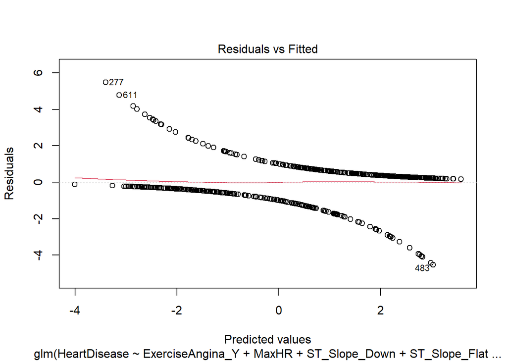

```r
plot(fit10,1)
```

Looking at the Residuals vs Fit plot, the data follows a linear trend. Residuals do seem to have a pattern, but that pattern of clusters is natural with a pearson plot. So this satisfies the assumptions that the predictors are linearly related.

## 15.2 Cook’s distance

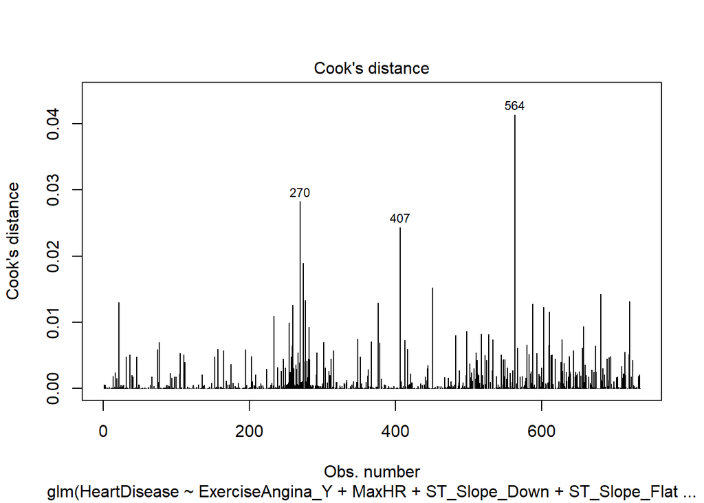

```r
plot(fit10,4)
```

According to the Cook’s distance plot there are three cases which are potential influential outliers: 270, 407 and especially 564. The Residuals vs Leverage plot will provide more detail on these observations.

## 15.3 Residuals vs Leverage

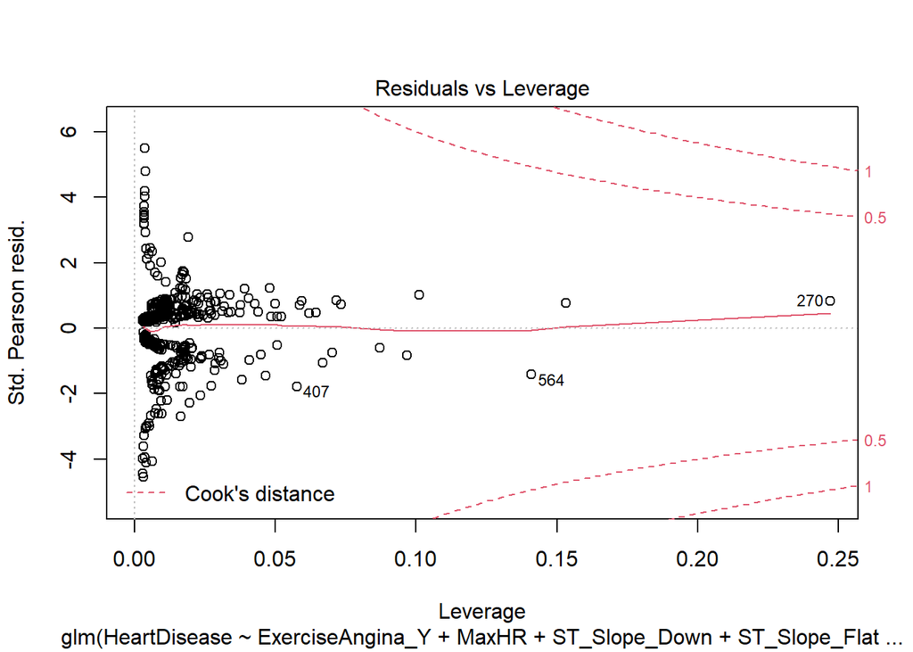

```r
plot(fit10,5)
```

# 16 Predictions

Now we will start working with the test set. We will make predictions in the probability scale plugging in our best model *fit10* to the test set.

After getting the probabilities prediction, we need to set a threshold in order to classify the outcomes in the two groups of heart disease: the normal group (the ones with healthy heart) and the problematic group (the ones with heart disease).

We will use the 50% probability as the cut off. As we are trying to predict heart disease, we will consider the success group as the problematic one (“Prob”).

If the (predicted) probability is higher than 50%, the person will be classified as having heart disease; if the (predicted) probability is lower or equal to 50%, the person is classified in the group of normal hearts.

```r
# Creating the dummy codes in the test set
test_heart_dummy <- dummy_cols(test_heart,
                        select_columns = c('ExerciseAngina', 'ST_Slope'))

# Predictions in the probability scale
probab <- predict(fit10, newdata = test_heart_dummy, type = "response")

# Add column of predictions to the test set
test_heart_dummy$prediction <- probab

# Setting a cut off at 50%
class <- ifelse(probab > 0.5, "Prob", "Norm") %>% factor()

# Add column of predicted classification to the test set
test_heart_dummy$classification <- class

# Selecting variables to visualize
test_heart_pred <- test_heart_dummy %>%
                   select(MaxHR, Oldpeak, ExerciseAngina_Y, ST_Slope_Down,
                          ST_Slope_Flat, HeartDisease, prediction, classification)

# Visualizing dataset
head(test_heart_pred) %>%
  knitr::kable(format = "markdown", digits= 1, padding = 30, align = 'c')
```

| MaxHR | Oldpeak | ExerciseAngina_Y | ST_Slope_Down | ST_Slope_Flat | HeartDisease | prediction | classification |
| --- | --- | --- | --- | --- | --- | --- | --- |
| 108 | 1.5 | 1 | 0 | 1 | Prob | 0.9 | Prob |
| 142 | 0.0 | 0 | 0 | 0 | Norm | 0.1 | Norm |
| 166 | 0.0 | 0 | 0 | 1 | Prob | 0.6 | Prob |
| 164 | 0.0 | 0 | 0 | 0 | Norm | 0.1 | Norm |
| 178 | 0.0 | 0 | 0 | 0 | Norm | 0.1 | Norm |
| 145 | 0.0 | 0 | 0 | 0 | Norm | 0.1 | Norm |

# 17 Confusion Matrix

We will check the out of sample performance of our model with a confusion matrix. The dataset was split in test and train sets in the beginning of the assignment. No we work with the test set to see what is the accuracy of *fit10* in a different sample than the one in which we trained the model.

The test set has 183 observations, of which 66 are true negatives; 91 are true positives; 10 are false negatives; and 16 are false positives.

With this result, we can interpret the *sensitivity*, *specificity* and *accuracy*. Before doing so, it is important to pay attention to the last line of the output.

“‘Positive’ Class : Norm” means that the machine is considering *Norm* as the success group. As said in the topic above, our analysis consider *Prob* as the success group, as soon as we are predicting heart disease -but R does not know it. Because of that, we will have to switch the output for specificity and sensitivity.

```r
confusionMatrix(class, reference = test_heart_dummy$HeartDisease)
```

```
## Confusion Matrix and Statistics
##
##           Reference
## Prediction Norm Prob
##       Norm   66   10
##       Prob   16   91
##
##                Accuracy : 0.8579
##                  95% CI : (0.7988, 0.905)
##     No Information Rate : 0.5519
##     P-Value [Acc > NIR] : <2e-16
##
##                   Kappa : 0.7108
##
##  Mcnemar's Test P-Value : 0.3268
##
##             Sensitivity : 0.8049
##             Specificity : 0.9010
##          Pos Pred Value : 0.8684
##          Neg Pred Value : 0.8505
##              Prevalence : 0.4481
##          Detection Rate : 0.3607
##    Detection Prevalence : 0.4153
##       Balanced Accuracy : 0.8529
##
##        'Positive' Class : Norm
##
```

## 17.1 Sensitivity

Sensitivity is a measure of how well we can predict membership in the positive class or, in other words, the true positives. Our model *fit10* has a sensitivity equal to 0.901. This means that there is a 90,1% probability that the model will predict heart disease when the person inideed has heart problems.

## 17.2 Specificity

On the other hand, specificity is a measure of how well we can predict a negative classification or, in other words, the true negatives. It is important to say that sensitivity and specificity are not complementary (they do not sum up 100% together), and a good model should have a high sensitivity and a high specificity.

*Fit10* has a specificity of 0.8049. This means that there is a 80,49% chance that the model will indicate no heart disease when the person indeed has a normal heart.

## 17.3 Accuracy

Accuracy is the proportion of cases we correctly classified: it is the sum of the true positive and true negatives divided total result. *Fit10* has an accuracy of 0.8579, which means that 85,79% chance of making a true prediction, whether negative or positive.

## 17.4 Error rate

The error rate speaks for itself and it is the proportion of cases that the model incorrectly predicts. Accuracy is complementary to accuracy: it is calculated by 1 - accuracy. it also can be calculated as the sum of false positives and false negatives divided by the total result.

*Fit10* has an error rate of 0.1421 and, therefore, has 14,21% probability of making a false prediction.

A good model has a high accuracy and low error rate.

## 17.5 ROC Curve

After getting all these measures above, we can use ROC (Receiver Operating Characteristic) Curve to visualize the performance of our binary classifier.

The curve is plotted with the false positive rate on x-axis and true positive rate on y-axis for all possible thresholds. Both false positive rate and true positive rate vary from 0 to 1.

We will analyse the ROC curve in our test set to avoid bias and overfit that we could get if we would have analysed the curve using our training set.

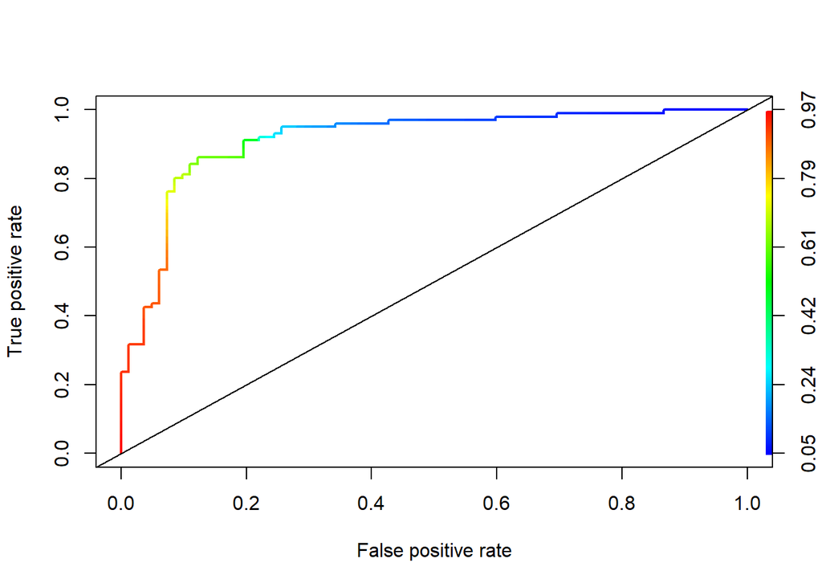

```r
# Duplicate HeartDisease column
test_heart_pred$prob_heart_obs <- test_heart_pred$HeartDisease

# Transform the categorical column Pron and Norm in 0 and 1. Prob will be 1
test_heart_pred$prob_heart_obs <- ifelse(test_heart_pred$prob_heart_obs == "Prob", 1, 0)

# Use observed values against predicted values to make the roc curve
pred <- prediction(test_heart_pred$prediction, test_heart_pred$prob_heart_obs)
roc_curve <- performance(pred, measure = "tpr", x.measure = "fpr")
plot(roc_curve, colorize = T, lwd = 2)
abline(a = 0, b = 1)
```

The AUC (area under the curve) is a good way of interpreting the graph. As the name suggest, it is about calculating the area that is under the ROC curve -in our case, the area between the colorful line and the x-axis. A bad result would be close to 0.5, exactly where the diagonal line crosses the chart. This result would mean a random prediction, similar to flipping a coin. A good result is as close to 1 as possible, when the ROC curve would reach the left upper corner of the graph.

As seen in the output bellow, the area under the curve in our chart is 0.913, meaning that we have a good classifier.

```r
# Getting the values for the area under the curve
auc <- performance(pred, measure = "auc")
print(auc@y.values)
```

```
## [[1]]
## [1] 0.9135475
```

# 18 Interpreting the final model

```r
fit10 <- glm(HeartDisease ~ ExerciseAngina_Y
                           + MaxHR
                           + ST_Slope_Down
                           + ST_Slope_Flat
                           + Oldpeak
                           + ST_Slope_Down * Oldpeak
                           + ST_Slope_Flat * Oldpeak,
              data = dummy_heart,
              family = "binomial")

summary(fit10)
```

```
##
## Call:
## glm(formula = HeartDisease ~ ExerciseAngina_Y + MaxHR + ST_Slope_Down +
##     ST_Slope_Flat + Oldpeak + ST_Slope_Down * Oldpeak + ST_Slope_Flat *
##     Oldpeak, family = "binomial", data = dummy_heart)
##
## Deviance Residuals:
##     Min       1Q   Median       3Q      Max
## -2.4803  -0.5144   0.3387   0.5842   2.6218
##
## Coefficients:
##                        Estimate Std. Error z value Pr(>|z|)
## (Intercept)            0.632451   0.679792   0.930   0.3522
## ExerciseAngina_Y       1.412272   0.236669   5.967 2.41e-09 ***
## MaxHR                 -0.019307   0.004584  -4.212 2.53e-05 ***
## ST_Slope_Down          1.512742   0.686454   2.204   0.0275 *
## ST_Slope_Flat          2.797008   0.279758   9.998  < 2e-16 ***
## Oldpeak                1.077656   0.206906   5.208 1.90e-07 ***
## ST_Slope_Down:Oldpeak -0.790886   0.356585  -2.218   0.0266 *
## ST_Slope_Flat:Oldpeak -1.037129   0.248101  -4.180 2.91e-05 ***
## ---
## Signif. codes:  0 '***' 0.001 '**' 0.01 '*' 0.05 '.' 0.1 ' ' 1
##
## (Dispersion parameter for binomial family taken to be 1)
##
##     Null deviance: 1010.42  on 734  degrees of freedom
## Residual deviance:  602.47  on 727  degrees of freedom
## AIC: 618.47
##
## Number of Fisher Scoring iterations: 5
```

The reference groups are in this case *ExerciseAngina_N* and *ST_Slope_Up*.

For an additional unit of *MaxHR*, the log odds of having a heart disease versus a normal performance decreases by **0.02**, after controlling for presence of an excercise angina, types of slopes and values of oldpeak. The effect is significant. The higher the maximum heart rate detected, the less chance the patient has of heart disease diagnosis.

For an additional unit of *Oldpeak*, the the log odds of having a heart disease versus a normal performance significantly increases with **1.08**, after controlling for other predictors. The higher the values of oldpeak, the bigger chance there is for having a heart disease.

Having an excersise induced angina (*ExerciseAngina_Y*) versus none (*ExerciseAngina_N*), changes the log odds of diagnosed heart by **1.41**, when the other predictors are at fixed values.

For the groups within the predictor *ST_Slope*, patients with down slopes versus up slopes have an increase in log odds of probability of heart disease with **1.51**. For patients with flat slopes instead of up, the log odds of heart disease increase by **2.80**.

In the presence of moderation of *ST_Slope* by *Oldpeak*, there is a different effect of oldpeak on heart disease probability for down and flat slope versus up slopes. This moderation works both ways. The coefficient for oldpeak is the effect of oldpeak when *ST_Slope_Down* = 0 and *ST_Slope_Flat* = 0. For *ST_Slope_Up*, a one unit increase in oldpeak has a change in log odds of **1.08**. On the other hand, for down slopes, a one unit increase in oldpeak changes the log odds with (1.077656 - 0.790886) = **0.29**. and for flat slopes log odds change with (1.077656 - 1.037129) = **0.04**, so the effect of oldpeak in having a heart disease is weaker for focal groups.

```r
exp(cbind(OddsRatio = coef(fit10), confint(fit10)))
```

```
##                        OddsRatio     2.5 %     97.5 %
## (Intercept)            1.8822177 0.4957029  7.1502217
## ExerciseAngina_Y       4.1052714 2.5906625  6.5623479
## MaxHR                  0.9808783 0.9719750  0.9896262
## ST_Slope_Down          4.5391586 1.1816125 18.1716698
## ST_Slope_Flat         16.3955248 9.5825783 28.7418989
## Oldpeak                2.9377841 1.9784489  4.4688856
## ST_Slope_Down:Oldpeak  0.4534427 0.2246239  0.9233562
## ST_Slope_Flat:Oldpeak  0.3544707 0.2159387  0.5727590
```

The odds for an extra unit of *MaxHR* are **0.98**, which is close to 1, so there is an almost negligible association between the maximum heart rate and the outcome. For an extra unit of *Oldpeak* the odds of success are **2.94**, so higher values of oldpeak are 3 times as likely to have a heart disease diagnosed. Holding MaxHR and Oldpeak at fixed values, the odds of having a heart disease for *ExerciseAngina_Y* over the odds of *EA_N* are 4.11, so *Y* group is 4 times more likely to have a heart disease diagnosed. Patients with *ST_Slope_Down* 4 times as likely to have heart disease and patients with *ST_Slope_Flat* are 16 times as likely compared to *ST_Slope_Up*.

# 19 Visualization of the model

To visualise the probability of heart disease the regression coefficients in terms of *log odds*, will be exponentiated to *odds ratios* and then transformed into *probabilities*. The code for the plots is derived from R Club (2016).

These are the regression estimates which came out of the **fit10** expressed in *log odds*.

```r
fit10$coefficients
```

```
##           (Intercept)      ExerciseAngina_Y                 MaxHR
##            0.63245069            1.41227187           -0.01930688
##         ST_Slope_Down         ST_Slope_Flat               Oldpeak
##            1.51274167            2.79700842            1.07765558
## ST_Slope_Down:Oldpeak ST_Slope_Flat:Oldpeak
##           -0.79088630           -1.03712948
```

Saving the *log odds* coefficients for the equations.

```r
b0 <- fit10$coefficients[1]
EAy <- fit10$coefficients[2]
MH <- fit10$coefficients[3]
STd <- fit10$coefficients[4]
STf <- fit10$coefficients[5]
OP <- fit10$coefficients[6]
STd.OP <- fit10$coefficients[7]
STf.OP <- fit10$coefficients[8]
```

There are two continuous predictor variables against which the probability of the outcome can be plotted against. The first one is *MaxHR* and the other one is *Oldpeak*.

## 19.1 MaxHR as x and Oldpeak as mean

Entering the range of the predictor on the x-axis, in this case *MaxHR*.

```r
MH_range <- seq(from=min(dummy_heart$MaxHR), to=max(dummy_heart$MaxHR), by=.01)
```

By plugging in the mean as value of *Oldpeak*, the plots will be generated to show the relationship between *MaxHR* and the outcome for a patient with an average oldpeak.

```r
OP_val <- mean(dummy_heart$Oldpeak)
```

Computing the regression equations for each class of *ST_Slope* in logit terms.

```r
#The reference group - ST_Slope_Up
up_logits <- b0 +
  MH*MH_range +
  OP*OP_val +
  EAy*0 +
  STd*0 +
  STf*0 +
  STd.OP*MH_range*0 +
  STf.OP*MH_range*0 +
  STd.OP*OP_val*0 +
  STf.OP*OP_val*0

#The focal groups
down_logits <- b0 +
  MH*MH_range +
  OP*OP_val +
  EAy*0 +
  STd*1 +
  STf*0 +
  STd.OP*MH_range*1 +
  STf.OP*MH_range*0 +
  STd.OP*OP_val*1 +
  STf.OP*OP_val*0

flat_logits <- b0 +
  MH*MH_range +
  OP*OP_val +
  EAy*0 +
  STd*0 +
  STf*1 +
  STd.OP*MH_range*0 +
  STf.OP*MH_range*1 +
  STd.OP*OP_val*0 +
  STf.OP*OP_val*1
```

Computing the probabilities which are going to be plotted.

```r
up_probs <- exp(up_logits)/(1 + exp(up_logits))
down_probs <- exp(down_logits)/(1 + exp(down_logits))
flat_probs <- exp(flat_logits)/(1 + exp(flat_logits))
```

Making the graph of probabilities of heart disease against *MaxHR* and an average value of *Oldpeak* for *ST_Slope* groups.

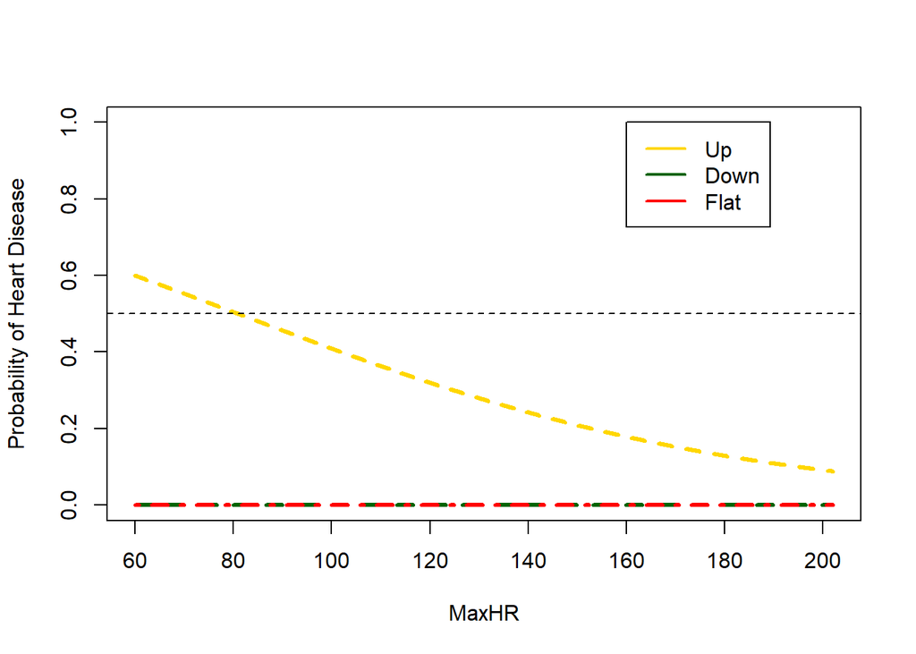

```r
#Plot for the reference group
plot(MH_range, up_probs,
     ylim=c(0,1),
     type="l",
     lwd=3,
     lty=2,
     col="gold",
     xlab="MaxHR", ylab="Probability of Heart Disease")

#Add the line for down slope
lines(MH_range, down_probs,
      type="l",
      lwd=3,
      lty=2,
      col="darkgreen")

#Add the line for flat slope
lines(MH_range, flat_probs,
      type="l",
      lwd=3,
      lty=4,
      col="red")

#Add a horizontal line at p=0.5
abline(h=0.5, lty=2)

legend(160, 1,
       c("Up", "Down", "Flat"),
       lty=c(1,1,1),
       lwd=c(2,2,2), col=c("gold", "darkgreen", "red")
       )
```

```r
#The reference group - ExerciseAngina_N
no_logits <- b0 +
  MH*MH_range +
  OP*OP_val +
  EAy*0 +
  STd*0 +
  STf*0 +
  STd.OP*MH_range*0 +
  STf.OP*MH_range*0 +
  STd.OP*OP_val*0 +
  STf.OP*OP_val*0

#The focal group - ExerciseAngina_Y
yes_logits <- b0 +
  MH*MH_range +
  OP*OP_val +
  EAy*1 +
  STd*0 +
  STf*0 +
  STd.OP*MH_range*0 +
  STf.OP*MH_range*0 +
  STd.OP*OP_val*0 +
  STf.OP*OP_val*0
```

Computing the probabilities which are going to be plotted.

```r
no_probs <- exp(no_logits)/(1 + exp(no_logits))
yes_probs <- exp(yes_logits)/(1 + exp(yes_logits))
```

Making the graph of probabilities of heart disease against *MaxHR* and an average value of *Oldpeak* for *ExerciseAngina* groups.

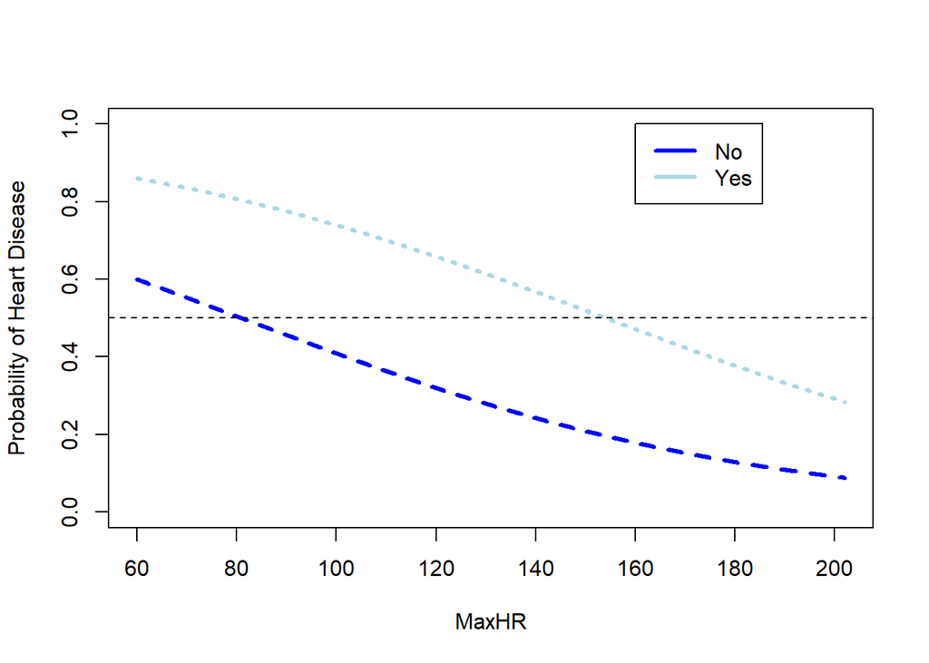

```r
#Plot for the reference group
plot(MH_range, no_probs,
     ylim=c(0,1),
     type="l",
     lwd=3,
     lty=2,
     col="blue",
     xlab="MaxHR", ylab="Probability of Heart Disease")

#Add the line for exercise angina yes-values
lines(MH_range, yes_probs,
      type="l",
      lwd=3,
      lty=3,
      col="lightblue")

#Add a horizontal line at p=0.5
abline(h=0.5, lty=2)

legend(160, 1,
       c("No", "Yes"),
       lty=c(1,1),
       lwd=c(3,3), col=c("blue", "lightblue")
       )
```

When oldpeak values are held at the mean, the patients with an exercise induced angina (yes) with MaxHR below 155 have a higher probability of having a heart disease. For no angina, the MaxHR detected above 80, means the lower probability of having a heart disease and less chance of being classified as problematic.

## 19.2 Oldpeak as x and MaxHR as mean

Entering the range of the second predictor on the x-axis, in this case *Oldpeak*.

```r
OP_range <- seq(from=min(dummy_heart$Oldpeak), to=max(dummy_heart$Oldpeak), by=.01)
```

By plugging in the mean as value of *MaxHR*, the plots will be generated to show the relationship between *Oldpeak* and the outcome for a patient with an average detected maximum heart rate.

```r
MH_val <- mean(dummy_heart$MaxHR)
```

Computing the regression equations for each class of *ST_Slope* in logit terms.

```r
#The reference group - ST_Slope_Up
up_logits <- b0 +
  OP*OP_range +
  MH*MH_val +
  EAy*0 +
  STd*0 +
  STf*0 +
  STd.OP*OP_range*0 +
  STf.OP*OP_range*0 +
  STd.OP*MH_val*0 +
  STf.OP*MH_val*0

#The focal groups
down_logits <- b0 +
  OP*OP_range +
  MH*MH_val +
  EAy*0 +
  STd*1 +
  STf*0 +
  STd.OP*OP_range*1 +
  STf.OP*OP_range*0 +
  STd.OP*MH_val*1 +
  STf.OP*MH_val*0

flat_logits <- b0 +
  OP*OP_range +
  MH*MH_val +
  EAy*0 +
  STd*0 +
  STf*1 +
  STd.OP*OP_range*0 +
  STf.OP*OP_range*1 +
  STd.OP*MH_val*0 +
  STf.OP*MH_val*1
```

Computing the probabilities which are going to be plotted.

```r
up_probs <- exp(up_logits)/(1 + exp(up_logits))
down_probs <- exp(down_logits)/(1 + exp(down_logits))
flat_probs <- exp(flat_logits)/(1 + exp(flat_logits))
```

Making the graph of probabilities of heart disease against *Oldpeak* and an average value of *MaxHR* for *ST_Slope* groups.

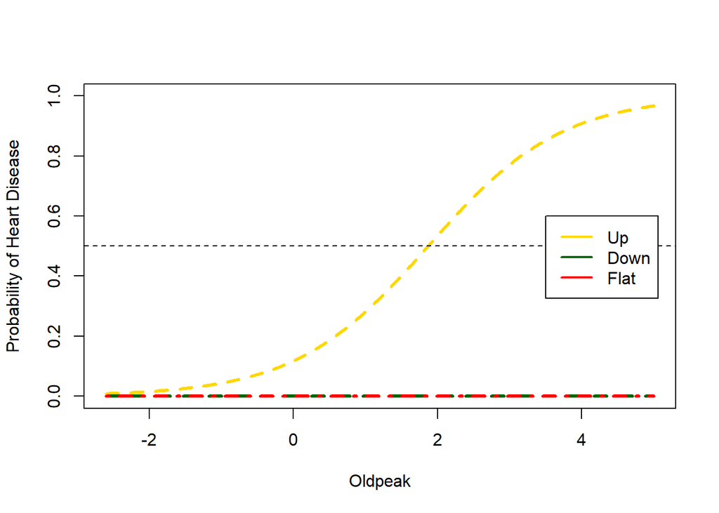

```r
#Plot for the reference group
plot(OP_range, up_probs,
     ylim=c(0,1),
     type="l",
     lwd=3,
     lty=2,
     col="gold",
     xlab="Oldpeak", ylab="Probability of Heart Disease")

#Add the line for down slope
lines(OP_range, down_probs,
      type="l",
      lwd=3,
      lty=2,
      col="darkgreen")

#Add the line for flat slope
lines(OP_range, flat_probs,
      type="l",
      lwd=3,
      lty=4,
      col="red")

#Add a horizontal line at p=0.5
abline(h=0.5, lty=2)

legend(3.5, 0.6,
       c("Up", "Down", "Flat"),
       lty=c(1,1,1),
       lwd=c(2,2,2), col=c("gold", "darkgreen", "red")
       )
```

Computing the regression equations for each class of *ExerciseAngina* in logit terms.

```r
#The reference group - ExerciseAngina_N
no_logits <- b0 +
  OP*OP_range +
  MH*MH_val +
  EAy*0 +
  STd*0 +
  STf*0 +
  STd.OP*OP_range*0 +
  STf.OP*OP_range*0 +
  STd.OP*MH_val*0 +
  STf.OP*MH_val*0

#The focal group - ExerciseAngina_Y
yes_logits <- b0 +
  OP*OP_range +
  MH*MH_val +
  EAy*1 +
  STd*0 +
  STf*0 +
  STd.OP*OP_range*0 +
  STf.OP*OP_range*0 +
  STd.OP*MH_val*0 +
  STf.OP*MH_val*0
```

Computing the probabilities which are going to be plotted.

```r
no_probs <- exp(no_logits)/(1 + exp(no_logits))
yes_probs <- exp(yes_logits)/(1 + exp(yes_logits))
```

Making the graph of probabilities of heart disease against *Oldpeak* and an average value of *MaxHR* for *ExerciseAngina* groups.

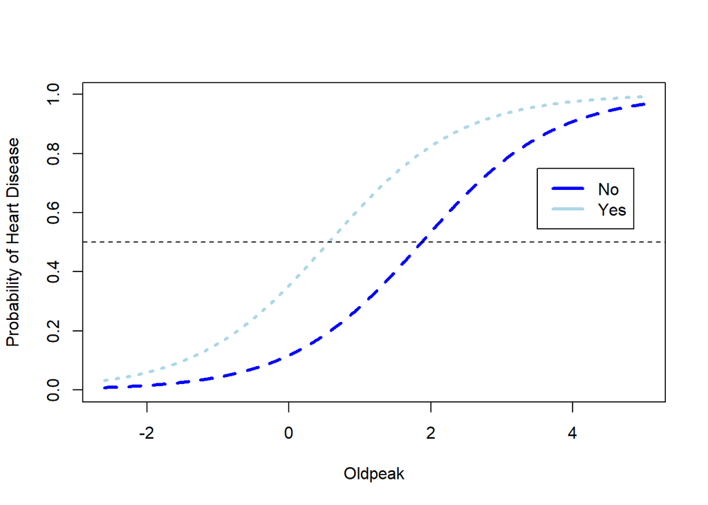

```r
#Plot for the reference group
plot(OP_range, no_probs,
     ylim=c(0,1),
     type="l",
     lwd=3,
     lty=2,
     col="blue",
     xlab="Oldpeak", ylab="Probability of Heart Disease")

#Add the line for exercise angina yes-values
lines(OP_range, yes_probs,
      type="l",
      lwd=3,
      lty=3,
      col="lightblue")

#Add a horizontal line at p=0.5
abline(h=0.5, lty=2)

legend(3.5, 0.75,
       c("No", "Yes"),
       lty=c(1,1),
       lwd=c(3,3), col=c("blue", "lightblue")
       )
```

# 20 Answering the research question

The research question that we tried to answer in this assignment, stated: **“When using exploratory data analysis, what variables seem to be influential predicting heart disease?”**

Since the data set we used contained 11 variables influencing heart disease, we started by exploring correlations between the variables and heart disease. Considering the results from the correlation analysis we decided to try and build a best model with the following 5 variables: *ExcerciseAngina*, *ST_Slope*, *MaxHR*, *Oldpeak*, and *Age*.

After a series of building the model, from simple additive logistic regression modelling to moderated multiple logistic regression modelling, we ended up with our best model  Model 10. When executing the model comparisons this model came out best with regard to ANOVA, AIC and BIC. The results of our best model suggest that people that experience angina after exercise (ExerciseAngina_Y), have a ST slope that is downwards or flat (ST_Slope_Flat & ST_Slope_Flat) and have greater depression in the ST segment (Oldpeak), have an increased log odds of heart disease. Furthermore, people that have a higher maximum heart rate (MaxHR) and an interaction term for either a downwards or flat ST slope (ST_Slope_Flat & ST_Slope_Flat) and a depression in the ST segment (Oldpeak), have a decreased log odds of heart disease. Thus, the variables **ExcerciseAngina_Y**, **MaxHR**, **ST_Slope_Down**, **ST_Slope_Flat**, **Oldpeak**, **ST_Slope_Down x Oldpeak** and **ST_Slope_Flat x Oldpeak**, seem to be the main factors to predict whether someone has heart failure or not.

Our goal when building this model was also to build a model that is accurate and shows low errors when predicting cases with new data. Our model has an accuracy of 85,79% and an AUC of 0,913. With regard to our outcome variable , *HeartDisease*, we are content with the way our model is able to do classifications. Since heart disease is a serious topic we would ultimately want a higher accuracy, yet the AUC is considered outstanding.

Surprisingly, even though we did not include hypothesis in our study (as a result of exploratory analysis), *Age* was not a significant predictor of heart failure. One could also argue that *RestingBP* was unexpectedly not even moderately related to heart failure when doing the correlation analysis. Maybe another research is needed to investigate these relationships.

# 21 Limitations

In our last topic, we will talk about the limitations faced during the development of this assignment. The first one to mention is our limitation to interpret the interaction added in our best model *fit10*.

The addition of the interactions between *ST_Slope_Down* and *Oldpeak*, and *ST_Slope_Flat* and *Oldpeak* was worth due to the improvement in the performance of the model, but it was random and not based on any hypothesis about a moderation. Because of that, we are not allowed to say which of the variables (*ST_slope* and *Oldpeak*) is the moderator and which is the focal predictor. It would not be ethical to look for a hypothesis after finding an improvement in the model, so we will leave it for other researchers to dedicate themselves to reflect on the moderation between the two predictors.

The second barrier was about the main predictors. As mentioned before, our goal was to train a model that could predict well and not find causal relationships or the indispensable variables that predict heart disease. We also did not base our analysis in any hypothesis about the true causes of heart problems. Because of that, we may have left some important variable out of the model. This could be the case, for instance, of cholesterol. We left it out, because there were a lot of missing values and a weak correlation with the outcome.

We also would like to mention the fact that the distribution of observations per class in categorical variables was not equal for some predictors. For the classification of logistic regression to be more accurate, the count per group should ideally be more balanced. However, that might correspond with the rareness of types occurring in real life medical cases. Moreover, it is more important that the division in classes of the outcome group has a balanced number of observations.

The last limitation we faced was a technical issue. When making the model comparison, we would like to add an extra criterion, besides the BIC, AIC and change in the deviance. We planned on performing a cross-validation through CVbinary() in order to get an estimate of accuracy, but because of and unknown problem, we were only able to get a zero result, as follows:

Fold: 1 5 9 10 4 2 8 7 3 6  
Internal estimate of accuracy = 0  
Cross-validation estimate of accuracy = 0

But it is here registered our attempt and concern about including this criterion, in addition to the code we would use to obtain this result.

```r
# Comparing additive models

# Result for fit1
set.seed(42)
cross1 <- CVbinary(fit1, nfolds = 10)
```

```
##
## Fold:  1 5 9 10 4 2 8 7 3 6
## Internal estimate of accuracy = 0
## Cross-validation estimate of accuracy = 0
```

```r
# Result for fit2
set.seed(42)
cross2 <- CVbinary(fit2, nfolds = 10)
```

```
##
## Fold:  1 5 9 10 4 2 8 7 3 6
## Internal estimate of accuracy = 0
## Cross-validation estimate of accuracy = 0
```

```r
# Result for fit 3
set.seed(42)
cross3 <- CVbinary(fit3, nfolds = 10)
```

```
##
## Fold:  1 5 9 10 4 2 8 7 3 6
## Internal estimate of accuracy = 0
## Cross-validation estimate of accuracy = 0
```

```r
# Result for fit 4
set.seed(42)
cross4 <- CVbinary(fit4, nfolds = 10)
```

```
##
## Fold:  1 5 9 10 4 2 8 7 3 6
## Internal estimate of accuracy = 0
## Cross-validation estimate of accuracy = 0
```

```r
# Comparing the additive models 1, 2, 3 and 4
c(fit1 = cross1$acc.cv, fit2 = cross2$acc.cv, fit3 = cross3$acc.cv, fit4 = cross4$acc.cv)
```

```
## fit1 fit2 fit3 fit4
##    0    0    0    0
```

```r
# Now, comparing the moderated models

# Result for fit 5
set.seed(42)
cross5 <- CVbinary(fit5, nfolds = 10)
```

```
##
## Fold:  1 5 9 10 4 2 8 7 3 6
## Internal estimate of accuracy = 0
## Cross-validation estimate of accuracy = 0
```

```r
# Result for fit 6
set.seed(42)
cross6 <- CVbinary(fit6, nfolds = 10)
```

```
##
## Fold:  1 5 9 10 4 2 8 7 3 6
## Internal estimate of accuracy = 0
## Cross-validation estimate of accuracy = 0
```

```r
# Result for fit 7
set.seed(42)
cross7 <- CVbinary(fit7, nfolds = 10)
```

```
##
## Fold:  1 5 9 10 4 2 8 7 3 6
## Internal estimate of accuracy = 0
## Cross-validation estimate of accuracy = 0
```

```r
# Result for fit 8
set.seed(42)
cross8 <- CVbinary(fit8, nfolds = 10)
```

```
##
## Fold:  1 5 9 10 4 2 8 7 3 6
## Internal estimate of accuracy = 0
## Cross-validation estimate of accuracy = 0
```

```r
# Result for fit 9
set.seed(42)
cross9 <- CVbinary(fit9, nfolds = 10)
```

```
##
## Fold:  1 5 9 10 4 2 8 7 3 6
## Internal estimate of accuracy = 0
## Cross-validation estimate of accuracy = 0
```

```r
# Result for fit 10
set.seed(42)
cross10 <- CVbinary(fit10, nfolds = 10)
```

```
##
## Fold:  1 5 9 10 4 2 8 7 3 6
## Internal estimate of accuracy = 0
## Cross-validation estimate of accuracy = 0
```

```r
# Result for fit 11
set.seed(42)
cross11 <- CVbinary(fit11, nfolds = 10)
```

```
##
## Fold:  1 5 9 10 4 2 8 7 3 6
## Internal estimate of accuracy = 0
## Cross-validation estimate of accuracy = 0
```

```r
# Comparing the models 3, 5, 6, 7, 8, 9, 10 and 11
c(fit3 = cross3$acc.cv, fit5 = cross5$acc.cv, fit6 = cross6$acc.cv,
  fit7 = cross7$acc.cv, fit8 = cross8$acc.cv,
  fit9 = cross9$acc.cv, fit10 = cross10$acc.cv,
  fit11 = cross11$acc.cv)
```

```
##  fit3  fit5  fit6  fit7  fit8  fit9 fit10 fit11
##     0     0     0     0     0     0     0     0
```

# 22 Sources

Beerenwinkel, N., Ernst, F., Lengauer, T., Sander, O., Sing, T., & Unterthiner, T. (2020). *Package ‘ROCR’.* Retrieved from https://cran.r-project.org/web/packages/ROCR/ROCR.pdf

Fedesoriano. (2021, September). *Heart Failure Prediction Dataset.* [Data set] Retrieved from https://www.kaggle.com/fedesoriano/heart-failure-prediction.

Hastie, T., James, G., Tibshirani, R. & Witten, D. (2021). *An Introduction to Statistical Learning with Applications in R*. (2nd edition). Springer. Retrieved from https://hastie.su.domains/ISLR2/ISLRv2_website.pdf

Haira, K. (2018, 17 May). *dplyr - advanced-joining* Retrieved from https://rpubs.com/KunalHaria/390063.

Kassambara, A. (2018). Linear Regression Assumptions and Diagnostics in R: Essentials. In: *Statistical Tools for High-Throughput Data Analysis.* (1st edition). Retrieved from http://www.sthda.com/english/articles/39-regression-model-diagnostics/161-linear-regression-assumptions-and-diagnostics-in-r-essentials/#diagnostic-plots.

Klein, A. G., Gerhard, C., Büchner, R. D., Diestel, S. & Schermelleh-Engel, K. (2016). The detection of heteroscedasticity in regression models for psychological data. *Psychological Test and Assessment Modeling, 58*(4), 542-568.

Makowski, D., Ben-Shachar, M. S., Patil, I., & Lüdecke, D. (2019). Methods and Algorithms for Correlation Analysis in R. *Journal of Open Source Software, 5*(51), 2306. https://doi.org/10.21105/joss.02306

R Club (2016, April 5). *Plotting your logistic regression models.* [Blog] Retrieved from https://blogs.uoregon.edu/rclub/2016/04/05/plotting-your-logistic-regression-models/.

Rousselet, G. A., & Wilcox, R. R. (2020). Reaction times and other skewed distributions: problems with the mean and the median. *Meta-Psychology, 4*. Retrieved from https://doi.org/10.15626/MP.2019.1630

Svetunkov, I. & Yves, R. (2022). *Package ‘greybox’.* Retrieved from https://cran.r-project.org/web/packages/greybox/greybox.pdf.